# 3_Main_Analysis

# semantic - emoseg metric relationship across whole sample

##STEU/word-emo seg across conditions ###STEU

```r
model=lm(CEA_ave~STEU_score,data=all)
summary(model)
```

```
##
## Call:
## lm(formula = CEA_ave ~ STEU_score, data = all)
##
## Residuals:
##      Min       1Q   Median       3Q      Max
## -0.25478 -0.10083 -0.01316  0.10290  0.34799
##
## Coefficients:
##             Estimate Std. Error t value Pr(>|t|)
## (Intercept) 0.283388   0.066837   4.240 3.69e-05 ***
## STEU_score  0.008305   0.005363   1.549    0.123
## ---
## Signif. codes:  0 '***' 0.001 '**' 0.01 '*' 0.05 '.' 0.1 ' ' 1
##
## Residual standard error: 0.1342 on 167 degrees of freedom
##   (11 observations deleted due to missingness)
## Multiple R-squared:  0.01416,    Adjusted R-squared:  0.008253
## F-statistic: 2.398 on 1 and 167 DF,  p-value: 0.1234
```

```r
model=lm(CEA_ave~STEU_sub_score,data=all)
summary(model)
```

```
##
## Call:
## lm(formula = CEA_ave ~ STEU_sub_score, data = all)
##
## Residuals:
##      Min       1Q   Median       3Q      Max
## -0.27644 -0.09787 -0.01064  0.09960  0.36268
##
## Coefficients:
##                Estimate Std. Error t value Pr(>|t|)
## (Intercept)     0.34031    0.04332   7.857 3.68e-13 ***
## STEU_sub_score  0.07270    0.06637   1.095    0.275
## ---
## Signif. codes:  0 '***' 0.001 '**' 0.01 '*' 0.05 '.' 0.1 ' ' 1
##
## Residual standard error: 0.1345 on 177 degrees of freedom
##   (1 observation deleted due to missingness)
## Multiple R-squared:  0.006732,   Adjusted R-squared:  0.00112
## F-statistic:   1.2 on 1 and 177 DF,  p-value: 0.2749
```

```r
model=lm(CEA_ave~STEU_untrained,data=all)
summary(model)
```

```
##
## Call:
## lm(formula = CEA_ave ~ STEU_untrained, data = all)
##
## Residuals:
##      Min       1Q   Median       3Q      Max
## -0.26324 -0.09471 -0.01023  0.09929  0.32986
##
## Coefficients:
##                Estimate Std. Error t value Pr(>|t|)
## (Intercept)     0.30110    0.04935   6.102 6.62e-09 ***
## STEU_untrained  0.13246    0.07331   1.807   0.0725 .
## ---
## Signif. codes:  0 '***' 0.001 '**' 0.01 '*' 0.05 '.' 0.1 ' ' 1
##
## Residual standard error: 0.1331 on 174 degrees of freedom
##   (4 observations deleted due to missingness)
## Multiple R-squared:  0.01842,    Adjusted R-squared:  0.01278
## F-statistic: 3.265 on 1 and 174 DF,  p-value: 0.07252
```

```r
model=lm(dprime~STEU_score,data=all)
summary(model)
```

```
##
## Call:
## lm(formula = dprime ~ STEU_score, data = all)
##
## Residuals:
##      Min       1Q   Median       3Q      Max
## -1.00480 -0.30620 -0.03471  0.23760  1.12291
##
## Coefficients:
##             Estimate Std. Error t value Pr(>|t|)
## (Intercept) -0.50523    0.20626  -2.450   0.0153 *
## STEU_score   0.02355    0.01657   1.422   0.1570
## ---
## Signif. codes:  0 '***' 0.001 '**' 0.01 '*' 0.05 '.' 0.1 ' ' 1
##
## Residual standard error: 0.4164 on 168 degrees of freedom
##   (10 observations deleted due to missingness)
## Multiple R-squared:  0.01189,    Adjusted R-squared:  0.006005
## F-statistic: 2.021 on 1 and 168 DF,  p-value: 0.157
```

```r
model=lm(dprime~STEU_sub_score,data=all)
summary(model)
```

```
##
## Call:
## lm(formula = dprime ~ STEU_sub_score, data = all)
##
## Residuals:
##      Min       1Q   Median       3Q      Max
## -0.99445 -0.30865 -0.03019  0.24376  1.04860
##
## Coefficients:
##                Estimate Std. Error t value Pr(>|t|)
## (Intercept)     -0.3692     0.1335  -2.766  0.00628 **
## STEU_sub_score   0.2444     0.2048   1.194  0.23420
## ---
## Signif. codes:  0 '***' 0.001 '**' 0.01 '*' 0.05 '.' 0.1 ' ' 1
##
## Residual standard error: 0.4159 on 178 degrees of freedom
## Multiple R-squared:  0.007941,   Adjusted R-squared:  0.002368
## F-statistic: 1.425 on 1 and 178 DF,  p-value: 0.2342
```

```r
model=lm(dprime~STEU_untrained,data=all)
summary(model)
```

```
##
## Call:
## lm(formula = dprime ~ STEU_untrained, data = all)
##
## Residuals:
##      Min       1Q   Median       3Q      Max
## -0.99992 -0.31246 -0.02825  0.25705  1.21375
##
## Coefficients:
##                Estimate Std. Error t value Pr(>|t|)
## (Intercept)     -0.4724     0.1527  -3.093  0.00231 **
## STEU_untrained   0.4015     0.2271   1.768  0.07881 .
## ---
## Signif. codes:  0 '***' 0.001 '**' 0.01 '*' 0.05 '.' 0.1 ' ' 1
##
## Residual standard error: 0.4132 on 175 degrees of freedom
##   (3 observations deleted due to missingness)
## Multiple R-squared:  0.01755,    Adjusted R-squared:  0.01193
## F-statistic: 3.126 on 1 and 175 DF,  p-value: 0.07881
```

```r
model=lm(accuracy~STEU_score,data=all)
summary(model)
```

```
##
## Call:
## lm(formula = accuracy ~ STEU_score, data = all)
##
## Residuals:
##       Min        1Q    Median        3Q       Max
## -0.197131 -0.046541 -0.006308  0.041485  0.188042
##
## Coefficients:
##             Estimate Std. Error t value Pr(>|t|)
## (Intercept) 0.416957   0.036216  11.513   <2e-16 ***
## STEU_score  0.004220   0.002909   1.451    0.149
## ---
## Signif. codes:  0 '***' 0.001 '**' 0.01 '*' 0.05 '.' 0.1 ' ' 1
##
## Residual standard error: 0.07311 on 168 degrees of freedom
##   (10 observations deleted due to missingness)
## Multiple R-squared:  0.01237,    Adjusted R-squared:  0.006496
## F-statistic: 2.105 on 1 and 168 DF,  p-value: 0.1487
```

```r
model=lm(accuracy~STEU_sub_score,data=all)
summary(model)
```

```
##
## Call:
## lm(formula = accuracy ~ STEU_sub_score, data = all)
##
## Residuals:
##       Min        1Q    Median        3Q       Max
## -0.194863 -0.047400 -0.006583  0.041036  0.176878
##
## Coefficients:
##                Estimate Std. Error t value Pr(>|t|)
## (Intercept)     0.44614    0.02335  19.104   <2e-16 ***
## STEU_sub_score  0.03685    0.03583   1.028    0.305
## ---
## Signif. codes:  0 '***' 0.001 '**' 0.01 '*' 0.05 '.' 0.1 ' ' 1
##
## Residual standard error: 0.07277 on 178 degrees of freedom
## Multiple R-squared:  0.005907,   Adjusted R-squared:  0.0003225
## F-statistic: 1.058 on 1 and 178 DF,  p-value: 0.3051
```

```r
model=lm(accuracy~STEU_untrained,data=all)
summary(model)
```

```
##
## Call:
## lm(formula = accuracy ~ STEU_untrained, data = all)
##
## Residuals:
##       Min        1Q    Median        3Q       Max
## -0.196071 -0.046788 -0.007101  0.041647  0.204160
##
## Coefficients:
##                Estimate Std. Error t value Pr(>|t|)
## (Intercept)     0.42357    0.02683  15.785   <2e-16 ***
## STEU_untrained  0.07069    0.03990   1.772   0.0782 .
## ---
## Signif. codes:  0 '***' 0.001 '**' 0.01 '*' 0.05 '.' 0.1 ' ' 1
##
## Residual standard error: 0.0726 on 175 degrees of freedom
##   (3 observations deleted due to missingness)
## Multiple R-squared:  0.01762,    Adjusted R-squared:  0.012
## F-statistic: 3.138 on 1 and 175 DF,  p-value: 0.07821
```

###fluency

```r
model=lm(CEA_ave~total_unique_word,data=all)
summary(model)
```

```
##
## Call:
## lm(formula = CEA_ave ~ total_unique_word, data = all)
##
## Residuals:
##      Min       1Q   Median       3Q      Max
## -0.27480 -0.09136 -0.00726  0.09986  0.33867
##
## Coefficients:
##                   Estimate Std. Error t value Pr(>|t|)
## (Intercept)       0.315277   0.028964  10.885  < 2e-16 ***
## total_unique_word 0.004270   0.001553   2.749  0.00662 **
## ---
## Signif. codes:  0 '***' 0.001 '**' 0.01 '*' 0.05 '.' 0.1 ' ' 1
##
## Residual standard error: 0.1315 on 173 degrees of freedom
##   (5 observations deleted due to missingness)
## Multiple R-squared:  0.04185,    Adjusted R-squared:  0.03631
## F-statistic: 7.555 on 1 and 173 DF,  p-value: 0.006618
```

```r
#significant: higher total unique word higher CEA (b=0.004, p=0.0066)
```

```r
model=lm(CEA_ave~total_word,data=all)
summary(model)
```

```
##
## Call:
## lm(formula = CEA_ave ~ total_word, data = all)
##
## Residuals:
##      Min       1Q   Median       3Q      Max
## -0.26796 -0.08984 -0.01341  0.09931  0.33823
##
## Coefficients:
##             Estimate Std. Error t value Pr(>|t|)
## (Intercept) 0.329252   0.040004   8.230    6e-14 ***
## total_word  0.003422   0.002225   1.538    0.126
## ---
## Signif. codes:  0 '***' 0.001 '**' 0.01 '*' 0.05 '.' 0.1 ' ' 1
##
## Residual standard error: 0.1312 on 161 degrees of freedom
##   (17 observations deleted due to missingness)
## Multiple R-squared:  0.01447,    Adjusted R-squared:  0.008352
## F-statistic: 2.364 on 1 and 161 DF,  p-value: 0.1261
```

```r
model=lm(dprime~total_unique_word,data=all)
summary(model)
```

```
##
## Call:
## lm(formula = dprime ~ total_unique_word, data = all)
##
## Residuals:
##      Min       1Q   Median       3Q      Max
## -0.96280 -0.29653 -0.02762  0.23845  1.12217
##
## Coefficients:
##                    Estimate Std. Error t value Pr(>|t|)
## (Intercept)       -0.154463   0.091198  -1.694   0.0921 .
## total_unique_word -0.002742   0.004890  -0.561   0.5758
## ---
## Signif. codes:  0 '***' 0.001 '**' 0.01 '*' 0.05 '.' 0.1 ' ' 1
##
## Residual standard error: 0.4139 on 174 degrees of freedom
##   (4 observations deleted due to missingness)
## Multiple R-squared:  0.001803,   Adjusted R-squared:  -0.003934
## F-statistic: 0.3143 on 1 and 174 DF,  p-value: 0.5758
```

```r
model=lm(dprime~total_word,data=all)
summary(model)
```

```
##
## Call:
## lm(formula = dprime ~ total_word, data = all)
##
## Residuals:
##      Min       1Q   Median       3Q      Max
## -0.97425 -0.28715 -0.02859  0.24388  1.11571
##
## Coefficients:
##              Estimate Std. Error t value Pr(>|t|)
## (Intercept) -0.050220   0.126051  -0.398    0.691
## total_word  -0.008332   0.007009  -1.189    0.236
##
## Residual standard error: 0.4133 on 162 degrees of freedom
##   (16 observations deleted due to missingness)
## Multiple R-squared:  0.008647,   Adjusted R-squared:  0.002528
## F-statistic: 1.413 on 1 and 162 DF,  p-value: 0.2363
```

```r
model=lm(accuracy~total_unique_word,data=all)
summary(model)
```

```
##
## Call:
## lm(formula = accuracy ~ total_unique_word, data = all)
##
## Residuals:
##       Min        1Q    Median        3Q       Max
## -0.187158 -0.047675 -0.007414  0.041615  0.187380
##
## Coefficients:
##                     Estimate Std. Error t value Pr(>|t|)
## (Intercept)        0.4871453  0.0159692   30.50   <2e-16 ***
## total_unique_word -0.0009163  0.0008563   -1.07    0.286
## ---
## Signif. codes:  0 '***' 0.001 '**' 0.01 '*' 0.05 '.' 0.1 ' ' 1
##
## Residual standard error: 0.07248 on 174 degrees of freedom
##   (4 observations deleted due to missingness)
## Multiple R-squared:  0.006538,   Adjusted R-squared:  0.0008281
## F-statistic: 1.145 on 1 and 174 DF,  p-value: 0.2861
```

```r
model=lm(accuracy~total_word,data=all)
summary(model)
```

```
##
## Call:
## lm(formula = accuracy ~ total_word, data = all)
##
## Residuals:
##       Min        1Q    Median        3Q       Max
## -0.179112 -0.048827 -0.007221  0.042840  0.186656
##
## Coefficients:
##              Estimate Std. Error t value Pr(>|t|)
## (Intercept)  0.510084   0.022081  23.101   <2e-16 ***
## total_word  -0.002169   0.001228  -1.767   0.0792 .
## ---
## Signif. codes:  0 '***' 0.001 '**' 0.01 '*' 0.05 '.' 0.1 ' ' 1
##
## Residual standard error: 0.0724 on 162 degrees of freedom
##   (16 observations deleted due to missingness)
## Multiple R-squared:  0.0189, Adjusted R-squared:  0.01285
## F-statistic: 3.121 on 1 and 162 DF,  p-value: 0.07916
```

```r
model=lm(SegNum_ave~total_unique_word,data=all)
summary(model)
```

```
##
## Call:
## lm(formula = SegNum_ave ~ total_unique_word, data = all)
##
## Residuals:
##     Min      1Q  Median      3Q     Max
## -7.3320 -2.9580 -0.9719  1.5554 21.8470
##
## Coefficients:
##                   Estimate Std. Error t value Pr(>|t|)
## (Intercept)        4.98208    0.99334   5.015  1.3e-06 ***
## total_unique_word  0.20782    0.05327   3.902 0.000136 ***
## ---
## Signif. codes:  0 '***' 0.001 '**' 0.01 '*' 0.05 '.' 0.1 ' ' 1
##
## Residual standard error: 4.509 on 174 degrees of freedom
##   (4 observations deleted due to missingness)
## Multiple R-squared:  0.08044,    Adjusted R-squared:  0.07516
## F-statistic: 15.22 on 1 and 174 DF,  p-value: 0.0001364
```

```r
model=lm(SegNum_ave~total_word,data=all)
summary(model)
```

```
##
## Call:
## lm(formula = SegNum_ave ~ total_word, data = all)
##
## Residuals:
##    Min     1Q Median     3Q    Max
## -7.170 -2.824 -1.049  1.508 21.972
##
## Coefficients:
##             Estimate Std. Error t value Pr(>|t|)
## (Intercept)  5.08599    1.34440   3.783 0.000218 ***
## total_word   0.19576    0.07476   2.619 0.009666 **
## ---
## Signif. codes:  0 '***' 0.001 '**' 0.01 '*' 0.05 '.' 0.1 ' ' 1
##
## Residual standard error: 4.408 on 162 degrees of freedom
##   (16 observations deleted due to missingness)
## Multiple R-squared:  0.04061,    Adjusted R-squared:  0.03469
## F-statistic: 6.857 on 1 and 162 DF,  p-value: 0.009666
```

```r
model=lm(MLU_ave~total_unique_word,data=all)
summary(model)
```

```
##
## Call:
## lm(formula = MLU_ave ~ total_unique_word, data = all)
##
## Residuals:
##     Min      1Q  Median      3Q     Max
## -9.5782 -3.5548 -0.6026  2.7459 13.4812
##
## Coefficients:
##                   Estimate Std. Error t value Pr(>|t|)
## (Intercept)       16.35855    1.17316  13.944  < 2e-16 ***
## total_unique_word -0.19310    0.06385  -3.024  0.00288 **
## ---
## Signif. codes:  0 '***' 0.001 '**' 0.01 '*' 0.05 '.' 0.1 ' ' 1
##
## Residual standard error: 5.018 on 169 degrees of freedom
##   (9 observations deleted due to missingness)
## Multiple R-squared:  0.05134,    Adjusted R-squared:  0.04572
## F-statistic: 9.145 on 1 and 169 DF,  p-value: 0.002883
```

```r
model=lm(MLU_ave~total_word,data=all)
summary(model)
```

```
##
## Call:
## lm(formula = MLU_ave ~ total_word, data = all)
##
## Residuals:
##     Min      1Q  Median      3Q     Max
## -9.5527 -3.3127 -0.6511  2.4457 13.2739
##
## Coefficients:
##             Estimate Std. Error t value Pr(>|t|)
## (Intercept)  17.2322     1.5607   11.04  < 2e-16 ***
## total_word   -0.2404     0.0868   -2.77  0.00628 **
## ---
## Signif. codes:  0 '***' 0.001 '**' 0.01 '*' 0.05 '.' 0.1 ' ' 1
##
## Residual standard error: 5.03 on 158 degrees of freedom
##   (20 observations deleted due to missingness)
## Multiple R-squared:  0.04631,    Adjusted R-squared:  0.04028
## F-statistic: 7.673 on 1 and 158 DF,  p-value: 0.006278
```

##Whether condition effect of emoseg preserve controlling for STEU & emo word ###STEU

```r
model=lm(CEA_ave~condition+STEU_score,data=all)
summary(model)
```

```
##
## Call:
## lm(formula = CEA_ave ~ condition + STEU_score, data = all)
##
## Residuals:
##       Min        1Q    Median        3Q       Max
## -0.265345 -0.078917 -0.004097  0.072518  0.312885
##
## Coefficients:
##                     Estimate Std. Error t value Pr(>|t|)
## (Intercept)         0.366162   0.060243   6.078 8.15e-09 ***
## conditionNoLabel    0.067143   0.022917   2.930 0.003872 **
## conditionWithLabel -0.089859   0.023077  -3.894 0.000143 ***
## STEU_score          0.002022   0.004804   0.421 0.674361
## ---
## Signif. codes:  0 '***' 0.001 '**' 0.01 '*' 0.05 '.' 0.1 ' ' 1
##
## Residual standard error: 0.1176 on 165 degrees of freedom
##   (11 observations deleted due to missingness)
## Multiple R-squared:  0.2525, Adjusted R-squared:  0.2389
## F-statistic: 18.57 on 3 and 165 DF,  p-value: 1.979e-10
```

```r
library(car)
Anova(model,type=2)
```

```
## Anova Table (Type II tests)
##
## Response: CEA_ave
##             Sum Sq  Df F value    Pr(>F)
## condition  0.72718   2 26.2988 1.219e-10 ***
## STEU_score 0.00245   1  0.1772    0.6744
## Residuals  2.28118 165
## ---
## Signif. codes:  0 '***' 0.001 '**' 0.01 '*' 0.05 '.' 0.1 ' ' 1
```

```r
model=lm(dprime~condition+STEU_score,data=all)
summary(model)
```

```
##
## Call:
## lm(formula = dprime ~ condition + STEU_score, data = all)
##
## Residuals:
##      Min       1Q   Median       3Q      Max
## -1.15171 -0.25595 -0.01486  0.27954  0.90101
##
## Coefficients:
##                    Estimate Std. Error t value Pr(>|t|)
## (Intercept)        -0.24448    0.19578  -1.249  0.21353
## conditionNoLabel   -0.20391    0.07469  -2.730  0.00702 **
## conditionWithLabel -0.42419    0.07494  -5.660  6.5e-08 ***
## STEU_score          0.02056    0.01561   1.317  0.18954
## ---
## Signif. codes:  0 '***' 0.001 '**' 0.01 '*' 0.05 '.' 0.1 ' ' 1
##
## Residual standard error: 0.3833 on 166 degrees of freedom
##   (10 observations deleted due to missingness)
## Multiple R-squared:  0.1728, Adjusted R-squared:  0.1578
## F-statistic: 11.56 on 3 and 166 DF,  p-value: 6.408e-07
```

```r
Anova(model,type=2)
```

```
## Anova Table (Type II tests)
##
## Response: dprime
##             Sum Sq  Df F value    Pr(>F)
## condition   4.7429   2 16.1445 3.919e-07 ***
## STEU_score  0.2549   1  1.7354    0.1895
## Residuals  24.3835 166
## ---
## Signif. codes:  0 '***' 0.001 '**' 0.01 '*' 0.05 '.' 0.1 ' ' 1
```

```r
model=lm(accuracy~condition+STEU_score,data=all)
summary(model)
```

```
##
## Call:
## lm(formula = accuracy ~ condition + STEU_score, data = all)
##
## Residuals:
##       Min        1Q    Median        3Q       Max
## -0.188937 -0.041584 -0.007986  0.045497  0.162498
##
## Coefficients:
##                     Estimate Std. Error t value Pr(>|t|)
## (Intercept)         0.456855   0.034762  13.143  < 2e-16 ***
## conditionNoLabel   -0.044659   0.013262  -3.368 0.000943 ***
## conditionWithLabel -0.069958   0.013306  -5.258 4.44e-07 ***
## STEU_score          0.004317   0.002771   1.558 0.121153
## ---
## Signif. codes:  0 '***' 0.001 '**' 0.01 '*' 0.05 '.' 0.1 ' ' 1
##
## Residual standard error: 0.06805 on 166 degrees of freedom
##   (10 observations deleted due to missingness)
## Multiple R-squared:  0.1546, Adjusted R-squared:  0.1393
## F-statistic: 10.12 on 3 and 166 DF,  p-value: 3.695e-06
```

```r
Anova(model,type=2)
```

```
## Anova Table (Type II tests)
##
## Response: accuracy
##             Sum Sq  Df F value   Pr(>F)
## condition  0.12933   2 13.9652 2.48e-06 ***
## STEU_score 0.01124   1  2.4272   0.1212
## Residuals  0.76867 166
## ---
## Signif. codes:  0 '***' 0.001 '**' 0.01 '*' 0.05 '.' 0.1 ' ' 1
```

```r
model=lm(CEA_ave~condition+STEU_sub_score,data=all)
summary(model)
```

```
##
## Call:
## lm(formula = CEA_ave ~ condition + STEU_sub_score, data = all)
##
## Residuals:
##       Min        1Q    Median        3Q       Max
## -0.272438 -0.081577 -0.004633  0.073509  0.308599
##
## Coefficients:
##                    Estimate Std. Error t value Pr(>|t|)
## (Intercept)         0.38477    0.04029   9.549  < 2e-16 ***
## conditionNoLabel    0.06737    0.02169   3.106  0.00222 **
## conditionWithLabel -0.09054    0.02220  -4.078 6.89e-05 ***
## STEU_sub_score      0.01034    0.05908   0.175  0.86134
## ---
## Signif. codes:  0 '***' 0.001 '**' 0.01 '*' 0.05 '.' 0.1 ' ' 1
##
## Residual standard error: 0.1184 on 175 degrees of freedom
##   (1 observation deleted due to missingness)
## Multiple R-squared:  0.2394, Adjusted R-squared:  0.2263
## F-statistic: 18.36 on 3 and 175 DF,  p-value: 2.115e-10
```

```r
Anova(model,type=2)
```

```
## Anova Table (Type II tests)
##
## Response: CEA_ave
##                 Sum Sq  Df F value    Pr(>F)
## condition      0.75023   2 26.7612 7.237e-11 ***
## STEU_sub_score 0.00043   1  0.0306    0.8613
## Residuals      2.45299 175
## ---
## Signif. codes:  0 '***' 0.001 '**' 0.01 '*' 0.05 '.' 0.1 ' ' 1
```

```r
model=lm(dprime~condition+STEU_sub_score,data=all)
summary(model)
```

```
##
## Call:
## lm(formula = dprime ~ condition + STEU_sub_score, data = all)
##
## Residuals:
##      Min       1Q   Median       3Q      Max
## -1.12065 -0.23137 -0.02912  0.28842  0.91803
##
## Coefficients:
##                    Estimate Std. Error t value Pr(>|t|)
## (Intercept)        -0.13791    0.13155  -1.048   0.2959
## conditionNoLabel   -0.16273    0.07090  -2.295   0.0229 *
## conditionWithLabel -0.39121    0.07229  -5.411 2.02e-07 ***
## STEU_sub_score      0.17457    0.19284   0.905   0.3666
## ---
## Signif. codes:  0 '***' 0.001 '**' 0.01 '*' 0.05 '.' 0.1 ' ' 1
##
## Residual standard error: 0.387 on 176 degrees of freedom
## Multiple R-squared:  0.1509, Adjusted R-squared:  0.1364
## F-statistic: 10.42 on 3 and 176 DF,  p-value: 2.393e-06
```

```r
Anova(model,type=2)
```

```
## Anova Table (Type II tests)
##
## Response: dprime
##                 Sum Sq  Df F value    Pr(>F)
## condition       4.4368   2 14.8121 1.134e-06 ***
## STEU_sub_score  0.1227   1  0.8194    0.3666
## Residuals      26.3591 176
## ---
## Signif. codes:  0 '***' 0.001 '**' 0.01 '*' 0.05 '.' 0.1 ' ' 1
```

```r
model=lm(accuracy~condition+STEU_sub_score,data=all)
summary(model)
```

```
##
## Call:
## lm(formula = accuracy ~ condition + STEU_sub_score, data = all)
##
## Residuals:
##       Min        1Q    Median        3Q       Max
## -0.184578 -0.041646 -0.006659  0.044728  0.173006
##
## Coefficients:
##                    Estimate Std. Error t value Pr(>|t|)
## (Intercept)         0.48547    0.02320  20.929  < 2e-16 ***
## conditionNoLabel   -0.03786    0.01250  -3.028  0.00283 **
## conditionWithLabel -0.06531    0.01275  -5.123 7.84e-07 ***
## STEU_sub_score      0.03014    0.03400   0.886  0.37660
## ---
## Signif. codes:  0 '***' 0.001 '**' 0.01 '*' 0.05 '.' 0.1 ' ' 1
##
## Residual standard error: 0.06824 on 176 degrees of freedom
## Multiple R-squared:  0.1358, Adjusted R-squared:  0.121
## F-statistic: 9.216 on 3 and 176 DF,  p-value: 1.075e-05
```

```r
Anova(model,type=2)
```

```
## Anova Table (Type II tests)
##
## Response: accuracy
##                 Sum Sq  Df F value    Pr(>F)
## condition      0.12314   2 13.2227 4.467e-06 ***
## STEU_sub_score 0.00366   1  0.7857    0.3766
## Residuals      0.81952 176
## ---
## Signif. codes:  0 '***' 0.001 '**' 0.01 '*' 0.05 '.' 0.1 ' ' 1
```

```r
model=lm(CEA_ave~condition+STEU_untrained,data=all)
summary(model)
```

```
##
## Call:
## lm(formula = CEA_ave ~ condition + STEU_untrained, data = all)
##
## Residuals:
##       Min        1Q    Median        3Q       Max
## -0.247290 -0.078010  0.002162  0.068822  0.309541
##
## Coefficients:
##                    Estimate Std. Error t value Pr(>|t|)
## (Intercept)         0.34644    0.04432   7.816 5.20e-13 ***
## conditionNoLabel    0.06517    0.02162   3.015  0.00296 **
## conditionWithLabel -0.09476    0.02184  -4.338 2.45e-05 ***
## STEU_untrained      0.07566    0.06466   1.170  0.24358
## ---
## Signif. codes:  0 '***' 0.001 '**' 0.01 '*' 0.05 '.' 0.1 ' ' 1
##
## Residual standard error: 0.1161 on 172 degrees of freedom
##   (4 observations deleted due to missingness)
## Multiple R-squared:  0.2625, Adjusted R-squared:  0.2497
## F-statistic: 20.41 on 3 and 172 DF,  p-value: 2.315e-11
```

```r
Anova(model,type=2)
```

```
## Anova Table (Type II tests)
##
## Response: CEA_ave
##                 Sum Sq  Df F value    Pr(>F)
## condition      0.76682   2 28.4658 2.093e-11 ***
## STEU_untrained 0.01844   1  1.3691    0.2436
## Residuals      2.31669 172
## ---
## Signif. codes:  0 '***' 0.001 '**' 0.01 '*' 0.05 '.' 0.1 ' ' 1
```

```r
model=lm(dprime~condition+STEU_untrained,data=all)
summary(model)
```

```
##
## Call:
## lm(formula = dprime ~ condition + STEU_untrained, data = all)
##
## Residuals:
##      Min       1Q   Median       3Q      Max
## -1.13238 -0.24696 -0.01588  0.25988  1.01236
##
## Coefficients:
##                    Estimate Std. Error t value Pr(>|t|)
## (Intercept)        -0.26714    0.14522  -1.840   0.0675 .
## conditionNoLabel   -0.17796    0.07092  -2.509   0.0130 *
## conditionWithLabel -0.40893    0.07137  -5.730 4.37e-08 ***
## STEU_untrained      0.39298    0.21181   1.855   0.0653 .
## ---
## Signif. codes:  0 '***' 0.001 '**' 0.01 '*' 0.05 '.' 0.1 ' ' 1
##
## Residual standard error: 0.3807 on 173 degrees of freedom
##   (3 observations deleted due to missingness)
## Multiple R-squared:  0.1755, Adjusted R-squared:  0.1612
## F-statistic: 12.28 on 3 and 173 DF,  p-value: 2.541e-07
```

```r
Anova(model,type=2)
```

```
## Anova Table (Type II tests)
##
## Response: dprime
##                 Sum Sq  Df F value    Pr(>F)
## condition       4.8058   2 16.5759 2.593e-07 ***
## STEU_untrained  0.4990   1  3.4422   0.06525 .
## Residuals      25.0786 173
## ---
## Signif. codes:  0 '***' 0.001 '**' 0.01 '*' 0.05 '.' 0.1 ' ' 1
```

```r
model=lm(accuracy~condition+STEU_untrained,data=all)
summary(model)
```

```
##
## Call:
## lm(formula = accuracy ~ condition + STEU_untrained, data = all)
##
## Residuals:
##       Min        1Q    Median        3Q       Max
## -0.185157 -0.043531 -0.002683  0.039353  0.168605
##
## Coefficients:
##                    Estimate Std. Error t value Pr(>|t|)
## (Intercept)         0.45719    0.02584  17.697  < 2e-16 ***
## conditionNoLabel   -0.03961    0.01262  -3.139  0.00199 **
## conditionWithLabel -0.06698    0.01270  -5.275 3.93e-07 ***
## STEU_untrained      0.07494    0.03768   1.989  0.04830 *
## ---
## Signif. codes:  0 '***' 0.001 '**' 0.01 '*' 0.05 '.' 0.1 ' ' 1
##
## Residual standard error: 0.06774 on 173 degrees of freedom
##   (3 observations deleted due to missingness)
## Multiple R-squared:  0.1546, Adjusted R-squared:  0.1399
## F-statistic: 10.55 on 3 and 173 DF,  p-value: 2.095e-06
```

```r
Anova(model,type=2)
```

```
## Anova Table (Type II tests)
##
## Response: accuracy
##                 Sum Sq  Df F value    Pr(>F)
## condition      0.12862   2 14.0160 2.283e-06 ***
## STEU_untrained 0.01815   1  3.9553    0.0483 *
## Residuals      0.79376 173
## ---
## Signif. codes:  0 '***' 0.001 '**' 0.01 '*' 0.05 '.' 0.1 ' ' 1
```

###fluency

```r
model=lm(CEA_ave~total_unique_word+condition,data=all)
summary(model)
```

```
##
## Call:
## lm(formula = CEA_ave ~ total_unique_word + condition, data = all)
##
## Residuals:
##      Min       1Q   Median       3Q      Max
## -0.27349 -0.08575  0.00079  0.07554  0.27192
##
## Coefficients:
##                     Estimate Std. Error t value Pr(>|t|)
## (Intercept)         0.327227   0.028522  11.473  < 2e-16 ***
## total_unique_word   0.003885   0.001369   2.837  0.00510 **
## conditionNoLabel    0.062503   0.021216   2.946  0.00367 **
## conditionWithLabel -0.090428   0.022077  -4.096 6.48e-05 ***
## ---
## Signif. codes:  0 '***' 0.001 '**' 0.01 '*' 0.05 '.' 0.1 ' ' 1
##
## Residual standard error: 0.1158 on 171 degrees of freedom
##   (5 observations deleted due to missingness)
## Multiple R-squared:  0.2655, Adjusted R-squared:  0.2526
## F-statistic: 20.61 on 3 and 171 DF,  p-value: 1.907e-11
```

```r
Anova(model,type=2)
```

```
## Anova Table (Type II tests)
##
## Response: CEA_ave
##                    Sum Sq  Df F value    Pr(>F)
## total_unique_word 0.10789   1  8.0508  0.005099 **
## condition         0.69788   2 26.0381 1.344e-10 ***
## Residuals         2.29160 171
## ---
## Signif. codes:  0 '***' 0.001 '**' 0.01 '*' 0.05 '.' 0.1 ' ' 1
```

```r
model=lm(dprime~condition+total_unique_word,data=all)
summary(model)
```

```
##
## Call:
## lm(formula = dprime ~ condition + total_unique_word, data = all)
##
## Residuals:
##      Min       1Q   Median       3Q      Max
## -1.14190 -0.22396 -0.02302  0.28356  0.93449
##
## Coefficients:
##                     Estimate Std. Error t value Pr(>|t|)
## (Intercept)         0.039068   0.094856   0.412   0.6809
## conditionNoLabel   -0.168473   0.070570  -2.387   0.0181 *
## conditionWithLabel -0.392538   0.073104  -5.370 2.53e-07 ***
## total_unique_word  -0.003108   0.004553  -0.683   0.4958
## ---
## Signif. codes:  0 '***' 0.001 '**' 0.01 '*' 0.05 '.' 0.1 ' ' 1
##
## Residual standard error: 0.3851 on 172 degrees of freedom
##   (4 observations deleted due to missingness)
## Multiple R-squared:  0.1461, Adjusted R-squared:  0.1312
## F-statistic: 9.812 on 3 and 172 DF,  p-value: 5.221e-06
```

```r
Anova(model,type=2)
```

```
## Anova Table (Type II tests)
##
## Response: dprime
##                    Sum Sq  Df F value   Pr(>F)
## condition          4.3104   2 14.5357 1.47e-06 ***
## total_unique_word  0.0691   1  0.4659   0.4958
## Residuals         25.5025 172
## ---
## Signif. codes:  0 '***' 0.001 '**' 0.01 '*' 0.05 '.' 0.1 ' ' 1
```

```r
model=lm(accuracy~condition+total_unique_word,data=all)
summary(model)
```

```
##
## Call:
## lm(formula = accuracy ~ condition + total_unique_word, data = all)
##
## Residuals:
##       Min        1Q    Median        3Q       Max
## -0.187839 -0.038753 -0.004143  0.044457  0.175801
##
## Coefficients:
##                      Estimate Std. Error t value Pr(>|t|)
## (Intercept)         0.5217919  0.0167993  31.060  < 2e-16 ***
## conditionNoLabel   -0.0372740  0.0124982  -2.982  0.00328 **
## conditionWithLabel -0.0638639  0.0129470  -4.933  1.9e-06 ***
## total_unique_word  -0.0009483  0.0008063  -1.176  0.24117
## ---
## Signif. codes:  0 '***' 0.001 '**' 0.01 '*' 0.05 '.' 0.1 ' ' 1
##
## Residual standard error: 0.0682 on 172 degrees of freedom
##   (4 observations deleted due to missingness)
## Multiple R-squared:  0.1307, Adjusted R-squared:  0.1155
## F-statistic: 8.617 on 3 and 172 DF,  p-value: 2.32e-05
```

```r
Anova(model,type=2)
```

```
## Anova Table (Type II tests)
##
## Response: accuracy
##                    Sum Sq  Df F value    Pr(>F)
## condition         0.11421   2 12.2793 1.035e-05 ***
## total_unique_word 0.00643   1  1.3833    0.2412
## Residuals         0.79990 172
## ---
## Signif. codes:  0 '***' 0.001 '**' 0.01 '*' 0.05 '.' 0.1 ' ' 1
```

```r
model=lm(SegNum_ave~condition+total_unique_word,data=all)
summary(model)
```

```
##
## Call:
## lm(formula = SegNum_ave ~ condition + total_unique_word, data = all)
##
## Residuals:
##    Min     1Q Median     3Q    Max
## -7.876 -2.665 -0.778  2.396 19.457
##
## Coefficients:
##                    Estimate Std. Error t value Pr(>|t|)
## (Intercept)         4.18262    1.01544   4.119 5.90e-05 ***
## conditionNoLabel    3.40297    0.75545   4.505 1.22e-05 ***
## conditionWithLabel -0.81751    0.78258  -1.045    0.298
## total_unique_word   0.19657    0.04874   4.033 8.26e-05 ***
## ---
## Signif. codes:  0 '***' 0.001 '**' 0.01 '*' 0.05 '.' 0.1 ' ' 1
##
## Residual standard error: 4.122 on 172 degrees of freedom
##   (4 observations deleted due to missingness)
## Multiple R-squared:  0.2402, Adjusted R-squared:  0.2269
## F-statistic: 18.12 on 3 and 172 DF,  p-value: 2.888e-10
```

```r
Anova(model,type=2)
```

```
## Anova Table (Type II tests)
##
## Response: SegNum_ave
##                    Sum Sq  Df F value    Pr(>F)
## condition          614.41   2  18.080 7.470e-08 ***
## total_unique_word  276.40   1  16.267 8.258e-05 ***
## Residuals         2922.52 172
## ---
## Signif. codes:  0 '***' 0.001 '**' 0.01 '*' 0.05 '.' 0.1 ' ' 1
```

```r
model=lm(MLU_ave~condition+total_unique_word,data=all)
summary(model)
```

```
##
## Call:
## lm(formula = MLU_ave ~ condition + total_unique_word, data = all)
##
## Residuals:
##      Min       1Q   Median       3Q      Max
## -10.5667  -3.3320  -0.4763   2.7734  11.2045
##
## Coefficients:
##                    Estimate Std. Error t value Pr(>|t|)
## (Intercept)        16.74264    1.17016  14.308  < 2e-16 ***
## conditionNoLabel   -3.37988    0.84972  -3.978 0.000104 ***
## conditionWithLabel  1.72325    0.87908   1.960 0.051627 .
## total_unique_word  -0.17428    0.05793  -3.008 0.003032 **
## ---
## Signif. codes:  0 '***' 0.001 '**' 0.01 '*' 0.05 '.' 0.1 ' ' 1
##
## Residual standard error: 4.545 on 167 degrees of freedom
##   (9 observations deleted due to missingness)
## Multiple R-squared:  0.231,  Adjusted R-squared:  0.2172
## F-statistic: 16.72 on 3 and 167 DF,  p-value: 1.514e-09
```

```r
Anova(model,type=2)
```

```
## Anova Table (Type II tests)
##
## Response: MLU_ave
##                   Sum Sq  Df F value    Pr(>F)
## condition          805.9   2 19.5089 2.431e-08 ***
## total_unique_word  186.9   1  9.0508  0.003032 **
## Residuals         3449.2 167
## ---
## Signif. codes:  0 '***' 0.001 '**' 0.01 '*' 0.05 '.' 0.1 ' ' 1
```

```r
model=lm(CEA_ave~total_word+condition,data=all)
summary(model)
```

```
##
## Call:
## lm(formula = CEA_ave ~ total_word + condition, data = all)
##
## Residuals:
##       Min        1Q    Median        3Q       Max
## -0.271926 -0.086188  0.001697  0.074816  0.276153
##
## Coefficients:
##                     Estimate Std. Error t value Pr(>|t|)
## (Intercept)         0.348366   0.037257   9.350  < 2e-16 ***
## total_word          0.002551   0.001984   1.286 0.200333
## conditionNoLabel    0.061254   0.022394   2.735 0.006940 **
## conditionWithLabel -0.086693   0.023280  -3.724 0.000272 ***
## ---
## Signif. codes:  0 '***' 0.001 '**' 0.01 '*' 0.05 '.' 0.1 ' ' 1
##
## Residual standard error: 0.1162 on 159 degrees of freedom
##   (17 observations deleted due to missingness)
## Multiple R-squared:  0.2358, Adjusted R-squared:  0.2214
## F-statistic: 16.35 on 3 and 159 DF,  p-value: 2.601e-09
```

```r
Anova(model,type=2)
```

```
## Anova Table (Type II tests)
##
## Response: CEA_ave
##             Sum Sq  Df F value    Pr(>F)
## total_word 0.02234   1  1.6536    0.2003
## condition  0.62198   2 23.0223 1.656e-09 ***
## Residuals  2.14780 159
## ---
## Signif. codes:  0 '***' 0.001 '**' 0.01 '*' 0.05 '.' 0.1 ' ' 1
```

```r
model=lm(dprime~condition+total_word,data=all)
summary(model)
```

```
##
## Call:
## lm(formula = dprime ~ condition + total_word, data = all)
##
## Residuals:
##      Min       1Q   Median       3Q      Max
## -1.16437 -0.21767 -0.02005  0.26366  0.93891
##
## Coefficients:
##                     Estimate Std. Error t value Pr(>|t|)
## (Intercept)         0.125751   0.123275   1.020   0.3092
## conditionNoLabel   -0.168224   0.074122  -2.270   0.0246 *
## conditionWithLabel -0.395313   0.076715  -5.153 7.47e-07 ***
## total_word         -0.007388   0.006563  -1.126   0.2619
## ---
## Signif. codes:  0 '***' 0.001 '**' 0.01 '*' 0.05 '.' 0.1 ' ' 1
##
## Residual standard error: 0.3847 on 160 degrees of freedom
##   (16 observations deleted due to missingness)
## Multiple R-squared:  0.1517, Adjusted R-squared:  0.1358
## F-statistic: 9.537 on 3 and 160 DF,  p-value: 7.855e-06
```

```r
Anova(model,type=2)
```

```
## Anova Table (Type II tests)
##
## Response: dprime
##             Sum Sq  Df F value    Pr(>F)
## condition   3.9928   2 13.4897 3.856e-06 ***
## total_word  0.1876   1  1.2675    0.2619
## Residuals  23.6791 160
## ---
## Signif. codes:  0 '***' 0.001 '**' 0.01 '*' 0.05 '.' 0.1 ' ' 1
```

```r
model=lm(accuracy~condition+total_word,data=all)
summary(model)
```

```
##
## Call:
## lm(formula = accuracy ~ condition + total_word, data = all)
##
## Residuals:
##       Min        1Q    Median        3Q       Max
## -0.192311 -0.041095 -0.001671  0.045885  0.179602
##
## Coefficients:
##                     Estimate Std. Error t value Pr(>|t|)
## (Intercept)         0.540783   0.021841  24.760  < 2e-16 ***
## conditionNoLabel   -0.036855   0.013133  -2.806  0.00563 **
## conditionWithLabel -0.064789   0.013592  -4.767 4.18e-06 ***
## total_word         -0.001916   0.001163  -1.648  0.10130
## ---
## Signif. codes:  0 '***' 0.001 '**' 0.01 '*' 0.05 '.' 0.1 ' ' 1
##
## Residual standard error: 0.06816 on 160 degrees of freedom
##   (16 observations deleted due to missingness)
## Multiple R-squared:  0.1412, Adjusted R-squared:  0.1251
## F-statistic: 8.767 on 3 and 160 DF,  p-value: 2.036e-05
```

```r
Anova(model,type=2)
```

```
## Anova Table (Type II tests)
##
## Response: accuracy
##             Sum Sq  Df F value    Pr(>F)
## condition  0.10582   2 11.3895 2.374e-05 ***
## total_word 0.01262   1  2.7161    0.1013
## Residuals  0.74331 160
## ---
## Signif. codes:  0 '***' 0.001 '**' 0.01 '*' 0.05 '.' 0.1 ' ' 1
```

```r
model=lm(SegNum_ave~condition+total_word,data=all)
summary(model)
```

```
##
## Call:
## lm(formula = SegNum_ave ~ condition + total_word, data = all)
##
## Residuals:
##     Min      1Q  Median      3Q     Max
## -7.6552 -2.7711 -0.7823  2.2918 19.8383
##
## Coefficients:
##                    Estimate Std. Error t value Pr(>|t|)
## (Intercept)         4.65408    1.30453   3.568 0.000476 ***
## conditionNoLabel    3.24218    0.78438   4.133 5.75e-05 ***
## conditionWithLabel -0.60285    0.81182  -0.743 0.458818
## total_word          0.16017    0.06945   2.306 0.022375 *
## ---
## Signif. codes:  0 '***' 0.001 '**' 0.01 '*' 0.05 '.' 0.1 ' ' 1
##
## Residual standard error: 4.071 on 160 degrees of freedom
##   (16 observations deleted due to missingness)
## Multiple R-squared:  0.1918, Adjusted R-squared:  0.1766
## F-statistic: 12.66 on 3 and 160 DF,  p-value: 1.819e-07
```

```r
Anova(model,type=2)
```

```
## Anova Table (Type II tests)
##
## Response: SegNum_ave
##             Sum Sq  Df F value    Pr(>F)
## condition   496.06   2 14.9659 1.101e-06 ***
## total_word   88.16   1  5.3192   0.02237 *
## Residuals  2651.70 160
## ---
## Signif. codes:  0 '***' 0.001 '**' 0.01 '*' 0.05 '.' 0.1 ' ' 1
```

```r
model=lm(MLU_ave~condition+total_word,data=all)
summary(model)
```

```
##
## Call:
## lm(formula = MLU_ave ~ condition + total_word, data = all)
##
## Residuals:
##      Min       1Q   Median       3Q      Max
## -10.4967  -3.6304  -0.3681   2.8846  11.2012
##
## Coefficients:
##                    Estimate Std. Error t value Pr(>|t|)
## (Intercept)        17.28063    1.50917  11.450  < 2e-16 ***
## conditionNoLabel   -3.23201    0.89842  -3.597 0.000431 ***
## conditionWithLabel  1.63800    0.93084   1.760 0.080418 .
## total_word         -0.20180    0.07972  -2.531 0.012356 *
## ---
## Signif. codes:  0 '***' 0.001 '**' 0.01 '*' 0.05 '.' 0.1 ' ' 1
##
## Residual standard error: 4.598 on 156 degrees of freedom
##   (20 observations deleted due to missingness)
## Multiple R-squared:  0.2131, Adjusted R-squared:  0.198
## F-statistic: 14.09 on 3 and 156 DF,  p-value: 3.586e-08
```

```r
Anova(model,type=2)
```

```
## Anova Table (Type II tests)
##
## Response: MLU_ave
##            Sum Sq  Df F value    Pr(>F)
## condition   699.2   2 16.5375 3.064e-07 ***
## total_word  135.4   1  6.4072   0.01236 *
## Residuals  3297.8 156
## ---
## Signif. codes:  0 '***' 0.001 '**' 0.01 '*' 0.05 '.' 0.1 ' ' 1
```

##Whether STEU-emoseg link vary across conditions? ###CEA

```
##
## Call:
## lm(formula = CEA_ave ~ STEU_score * condition, data = all)
##
## Residuals:
##       Min        1Q    Median        3Q       Max
## -0.257396 -0.077032  0.004891  0.078869  0.283694
##
## Coefficients:
##                                Estimate Std. Error t value Pr(>|t|)
## (Intercept)                    0.482312   0.133407   3.615 0.000399 ***
## STEU_score                    -0.007640   0.011006  -0.694 0.488585
## conditionNoLabel              -0.187448   0.164476  -1.140 0.256095
## conditionWithLabel            -0.125269   0.162252  -0.772 0.441196
## STEU_score:conditionNoLabel    0.020454   0.013270   1.541 0.125152
## STEU_score:conditionWithLabel  0.002924   0.013375   0.219 0.827225
## ---
## Signif. codes:  0 '***' 0.001 '**' 0.01 '*' 0.05 '.' 0.1 ' ' 1
##
## Residual standard error: 0.117 on 163 degrees of freedom
##   (11 observations deleted due to missingness)
## Multiple R-squared:  0.2689, Adjusted R-squared:  0.2465
## F-statistic: 11.99 on 5 and 163 DF,  p-value: 6.773e-10
```

```r
sim_slopes(
  model,
  STEU_score,
  condition,
  modx.values = NULL,
  centered = "all",
  cond.int = TRUE,
  confint=TRUE
)
```

```
## SIMPLE SLOPES ANALYSIS
##
## When condition = WithLabel:
##
##                                Est.   S.E.    2.5%   97.5%   t val.      p
## --------------------------- ------- ------ ------- ------- -------- ------
## Slope of STEU_score           -0.00   0.01   -0.02    0.01    -0.62   0.54
## Conditional intercept          0.36   0.09    0.17    0.54     3.87   0.00
##
## When condition = NoLabel:
##
##                               Est.   S.E.    2.5%   97.5%   t val.      p
## --------------------------- ------ ------ ------- ------- -------- ------
## Slope of STEU_score           0.01   0.01   -0.00    0.03     1.73   0.09
## Conditional intercept         0.29   0.10    0.10    0.48     3.07   0.00
##
## When condition = Counting:
##
##                                Est.   S.E.    2.5%   97.5%   t val.      p
## --------------------------- ------- ------ ------- ------- -------- ------
## Slope of STEU_score           -0.01   0.01   -0.03    0.01    -0.69   0.49
## Conditional intercept          0.48   0.13    0.22    0.75     3.62   0.00
```

```
##
## Call:
## lm(formula = CEA_ave ~ STEU_sub_score * condition, data = all)
##
## Residuals:
##       Min        1Q    Median        3Q       Max
## -0.269817 -0.080930  0.003016  0.075498  0.307471
##
## Coefficients:
##                                    Estimate Std. Error t value Pr(>|t|)
## (Intercept)                        0.387577   0.063816   6.073 7.73e-09 ***
## STEU_sub_score                     0.005863   0.098545   0.059    0.953
## conditionNoLabel                   0.019359   0.094444   0.205    0.838
## conditionWithLabel                -0.050951   0.092810  -0.549    0.584
## STEU_sub_score:conditionNoLabel    0.072603   0.142231   0.510    0.610
## STEU_sub_score:conditionWithLabel -0.065040   0.145824  -0.446    0.656
## ---
## Signif. codes:  0 '***' 0.001 '**' 0.01 '*' 0.05 '.' 0.1 ' ' 1
##
## Residual standard error: 0.1188 on 173 degrees of freedom
##   (1 observation deleted due to missingness)
## Multiple R-squared:  0.2431, Adjusted R-squared:  0.2213
## F-statistic: 11.11 on 5 and 173 DF,  p-value: 2.68e-09
```

```r
sim_slopes(
  model,
  STEU_sub_score,
  condition,
  modx.values = NULL,
  centered = "all",
  cond.int = TRUE,
  confint=TRUE
)
```

```
## SIMPLE SLOPES ANALYSIS
##
## When condition = WithLabel:
##
##                                  Est.   S.E.    2.5%   97.5%   t val.      p
## ----------------------------- ------- ------ ------- ------- -------- ------
## Slope of STEU_sub_score         -0.06   0.11   -0.27    0.15    -0.55   0.58
## Conditional intercept            0.34   0.07    0.20    0.47     5.00   0.00
##
## When condition = NoLabel:
##
##                                 Est.   S.E.    2.5%   97.5%   t val.      p
## ----------------------------- ------ ------ ------- ------- -------- ------
## Slope of STEU_sub_score         0.08   0.10   -0.12    0.28     0.77   0.45
## Conditional intercept           0.41   0.07    0.27    0.54     5.85   0.00
##
## When condition = Counting:
##
##                                 Est.   S.E.    2.5%   97.5%   t val.      p
## ----------------------------- ------ ------ ------- ------- -------- ------
## Slope of STEU_sub_score         0.01   0.10   -0.19    0.20     0.06   0.95
## Conditional intercept           0.39   0.06    0.26    0.51     6.07   0.00
```

```
##
## Call:
## lm(formula = CEA_ave ~ STEU_untrained * condition, data = all)
##
## Residuals:
##      Min       1Q   Median       3Q      Max
## -0.24683 -0.08527  0.00193  0.06955  0.31844
##
## Coefficients:
##                                   Estimate Std. Error t value Pr(>|t|)
## (Intercept)                        0.28691    0.07672   3.740 0.000251 ***
## STEU_untrained                     0.16847    0.11711   1.439 0.152094
## conditionNoLabel                   0.09239    0.11056   0.836 0.404500
## conditionWithLabel                 0.03998    0.10389   0.385 0.700848
## STEU_untrained:conditionNoLabel   -0.04578    0.16338  -0.280 0.779666
## STEU_untrained:conditionWithLabel -0.20929    0.15787  -1.326 0.186720
## ---
## Signif. codes:  0 '***' 0.001 '**' 0.01 '*' 0.05 '.' 0.1 ' ' 1
##
## Residual standard error: 0.1161 on 170 degrees of freedom
##   (4 observations deleted due to missingness)
## Multiple R-squared:  0.2711, Adjusted R-squared:  0.2497
## F-statistic: 12.65 on 5 and 170 DF,  p-value: 1.884e-10
```

```r
sim_slopes(
  model,
  STEU_untrained,
  condition,
  modx.values = NULL,
  centered = "all",
  cond.int = TRUE,
  confint=TRUE
)
```

```
## SIMPLE SLOPES ANALYSIS
##
## When condition = WithLabel:
##
##                                  Est.   S.E.    2.5%   97.5%   t val.      p
## ----------------------------- ------- ------ ------- ------- -------- ------
## Slope of STEU_untrained         -0.04   0.11   -0.25    0.17    -0.39   0.70
## Conditional intercept            0.33   0.07    0.19    0.47     4.67   0.00
##
## When condition = NoLabel:
##
##                                 Est.   S.E.    2.5%   97.5%   t val.      p
## ----------------------------- ------ ------ ------- ------- -------- ------
## Slope of STEU_untrained         0.12   0.11   -0.10    0.35     1.08   0.28
## Conditional intercept           0.38   0.08    0.22    0.54     4.76   0.00
##
## When condition = Counting:
##
##                                 Est.   S.E.    2.5%   97.5%   t val.      p
## ----------------------------- ------ ------ ------- ------- -------- ------
## Slope of STEU_untrained         0.17   0.12   -0.06    0.40     1.44   0.15
## Conditional intercept           0.29   0.08    0.14    0.44     3.74   0.00
```

```
##
## Call:
## lm(formula = CEA_ave ~ total_unique_word * condition, data = all)
##
## Residuals:
##       Min        1Q    Median        3Q       Max
## -0.273530 -0.080708 -0.001166  0.076493  0.271441
##
## Coefficients:
##                                       Estimate Std. Error t value Pr(>|t|)
## (Intercept)                           0.293882   0.038370   7.659 1.38e-12 ***
## total_unique_word                     0.005797   0.002011   2.882  0.00446 **
## conditionNoLabel                      0.091917   0.061246   1.501  0.13528
## conditionWithLabel                    0.007290   0.062472   0.117  0.90724
## total_unique_word:conditionNoLabel   -0.001692   0.003251  -0.520  0.60342
## total_unique_word:conditionWithLabel -0.005651   0.003380  -1.672  0.09640 .
## ---
## Signif. codes:  0 '***' 0.001 '**' 0.01 '*' 0.05 '.' 0.1 ' ' 1
##
## Residual standard error: 0.1155 on 169 degrees of freedom
##   (5 observations deleted due to missingness)
## Multiple R-squared:  0.2775, Adjusted R-squared:  0.2561
## F-statistic: 12.98 on 5 and 169 DF,  p-value: 1.076e-10
```

```r
sim_slopes(
  model,
  total_unique_word,
  condition,
  modx.values = NULL,
  centered = "all",
  cond.int = TRUE,
  confint=TRUE
)
```

```
## SIMPLE SLOPES ANALYSIS
##
## When condition = WithLabel:
##
##                                    Est.   S.E.    2.5%   97.5%   t val.      p
## -------------------------------- ------ ------ ------- ------- -------- ------
## Slope of total_unique_word         0.00   0.00   -0.01    0.01     0.05   0.96
## Conditional intercept              0.30   0.05    0.20    0.40     6.11   0.00
##
## When condition = NoLabel:
##
##                                    Est.   S.E.    2.5%   97.5%   t val.      p
## -------------------------------- ------ ------ ------- ------- -------- ------
## Slope of total_unique_word         0.00   0.00   -0.00    0.01     1.61   0.11
## Conditional intercept              0.39   0.05    0.29    0.48     8.08   0.00
##
## When condition = Counting:
##
##                                    Est.   S.E.   2.5%   97.5%   t val.      p
## -------------------------------- ------ ------ ------ ------- -------- ------
## Slope of total_unique_word         0.01   0.00   0.00    0.01     2.88   0.00
## Conditional intercept              0.29   0.04   0.22    0.37     7.66   0.00
```

```
##
## Call:
## lm(formula = CEA_ave ~ total_word * condition, data = all)
##
## Residuals:
##       Min        1Q    Median        3Q       Max
## -0.272436 -0.086395 -0.001382  0.075859  0.274656
##
## Coefficients:
##                                 Estimate Std. Error t value Pr(>|t|)
## (Intercept)                    0.3334390  0.0701684   4.752 4.52e-06 ***
## total_word                     0.0034409  0.0040612   0.847    0.398
## conditionNoLabel               0.0673112  0.0920201   0.731    0.466
## conditionWithLabel            -0.0530303  0.0913897  -0.580    0.563
## total_word:conditionNoLabel   -0.0003964  0.0051768  -0.077    0.939
## total_word:conditionWithLabel -0.0019786  0.0052134  -0.380    0.705
## ---
## Signif. codes:  0 '***' 0.001 '**' 0.01 '*' 0.05 '.' 0.1 ' ' 1
##
## Residual standard error: 0.1169 on 157 degrees of freedom
##   (17 observations deleted due to missingness)
## Multiple R-squared:  0.2367, Adjusted R-squared:  0.2124
## F-statistic: 9.736 on 5 and 157 DF,  p-value: 4.067e-08
```

```r
sim_slopes(
  model,
  total_word,
  condition,
  modx.values = NULL,
  centered = "all",
  cond.int = TRUE,
  confint=TRUE
)
```

```
## SIMPLE SLOPES ANALYSIS
##
## When condition = WithLabel:
##
##                               Est.   S.E.    2.5%   97.5%   t val.      p
## --------------------------- ------ ------ ------- ------- -------- ------
## Slope of total_word           0.00   0.00   -0.00    0.01     0.45   0.66
## Conditional intercept         0.28   0.06    0.16    0.40     4.79   0.00
##
## When condition = NoLabel:
##
##                               Est.   S.E.    2.5%   97.5%   t val.      p
## --------------------------- ------ ------ ------- ------- -------- ------
## Slope of total_word           0.00   0.00   -0.00    0.01     0.95   0.34
## Conditional intercept         0.40   0.06    0.28    0.52     6.73   0.00
##
## When condition = Counting:
##
##                               Est.   S.E.    2.5%   97.5%   t val.      p
## --------------------------- ------ ------ ------- ------- -------- ------
## Slope of total_word           0.00   0.00   -0.00    0.01     0.85   0.40
## Conditional intercept         0.33   0.07    0.19    0.47     4.75   0.00
```

###accuracy

```
##
## Call:
## lm(formula = accuracy ~ STEU_score * condition, data = all)
##
## Residuals:
##       Min        1Q    Median        3Q       Max
## -0.188817 -0.046208 -0.004897  0.047829  0.157873
##
## Coefficients:
##                                Estimate Std. Error t value Pr(>|t|)
## (Intercept)                    0.389171   0.077542   5.019 1.34e-06 ***
## STEU_score                     0.009948   0.006397   1.555    0.122
## conditionNoLabel              -0.004291   0.095600  -0.045    0.964
## conditionWithLabel             0.055603   0.093980   0.592    0.555
## STEU_score:conditionNoLabel   -0.003501   0.007713  -0.454    0.650
## STEU_score:conditionWithLabel -0.010474   0.007754  -1.351    0.179
## ---
## Signif. codes:  0 '***' 0.001 '**' 0.01 '*' 0.05 '.' 0.1 ' ' 1
##
## Residual standard error: 0.068 on 164 degrees of freedom
##   (10 observations deleted due to missingness)
## Multiple R-squared:  0.166,  Adjusted R-squared:  0.1406
## F-statistic: 6.529 on 5 and 164 DF,  p-value: 1.449e-05
```

```r
sim_slopes(
  model,
  STEU_score,
  condition,
  modx.values = NULL,
  centered = "all",
  cond.int = TRUE,
  confint=TRUE
)
```

```
## SIMPLE SLOPES ANALYSIS
##
## When condition = WithLabel:
##
##                                Est.   S.E.    2.5%   97.5%   t val.      p
## --------------------------- ------- ------ ------- ------- -------- ------
## Slope of STEU_score           -0.00   0.00   -0.01    0.01    -0.12   0.90
## Conditional intercept          0.44   0.05    0.34    0.55     8.38   0.00
##
## When condition = NoLabel:
##
##                               Est.   S.E.    2.5%   97.5%   t val.      p
## --------------------------- ------ ------ ------- ------- -------- ------
## Slope of STEU_score           0.01   0.00   -0.00    0.01     1.50   0.14
## Conditional intercept         0.38   0.06    0.27    0.50     6.88   0.00
##
## When condition = Counting:
##
##                               Est.   S.E.    2.5%   97.5%   t val.      p
## --------------------------- ------ ------ ------- ------- -------- ------
## Slope of STEU_score           0.01   0.01   -0.00    0.02     1.55   0.12
## Conditional intercept         0.39   0.08    0.24    0.54     5.02   0.00
```

```
##
## Call:
## lm(formula = accuracy ~ STEU_sub_score * condition, data = all)
##
## Residuals:
##       Min        1Q    Median        3Q       Max
## -0.184429 -0.040119 -0.006028  0.045799  0.172219
##
## Coefficients:
##                                   Estimate Std. Error t value Pr(>|t|)
## (Intercept)                        0.44348    0.03662  12.110   <2e-16 ***
## STEU_sub_score                     0.09707    0.05655   1.717   0.0878 .
## conditionNoLabel                   0.01772    0.05420   0.327   0.7441
## conditionWithLabel                 0.01108    0.05304   0.209   0.8348
## STEU_sub_score:conditionNoLabel   -0.08742    0.08162  -1.071   0.2856
## STEU_sub_score:conditionWithLabel -0.12351    0.08347  -1.480   0.1407
## ---
## Signif. codes:  0 '***' 0.001 '**' 0.01 '*' 0.05 '.' 0.1 ' ' 1
##
## Residual standard error: 0.06817 on 174 degrees of freedom
## Multiple R-squared:  0.1474, Adjusted R-squared:  0.1229
## F-statistic: 6.016 on 5 and 174 DF,  p-value: 3.674e-05
```

```r
sim_slopes(
  model,
  STEU_sub_score,
  condition,
  modx.values = NULL,
  centered = "all",
  cond.int = TRUE,
  confint=TRUE
)
```

```
## SIMPLE SLOPES ANALYSIS
##
## When condition = WithLabel:
##
##                                  Est.   S.E.    2.5%   97.5%   t val.      p
## ----------------------------- ------- ------ ------- ------- -------- ------
## Slope of STEU_sub_score         -0.03   0.06   -0.15    0.09    -0.43   0.67
## Conditional intercept            0.45   0.04    0.38    0.53    11.85   0.00
##
## When condition = NoLabel:
##
##                                 Est.   S.E.    2.5%   97.5%   t val.      p
## ----------------------------- ------ ------ ------- ------- -------- ------
## Slope of STEU_sub_score         0.01   0.06   -0.11    0.13     0.16   0.87
## Conditional intercept           0.46   0.04    0.38    0.54    11.54   0.00
##
## When condition = Counting:
##
##                                 Est.   S.E.    2.5%   97.5%   t val.      p
## ----------------------------- ------ ------ ------- ------- -------- ------
## Slope of STEU_sub_score         0.10   0.06   -0.01    0.21     1.72   0.09
## Conditional intercept           0.44   0.04    0.37    0.52    12.11   0.00
```

```
##
## Call:
## lm(formula = accuracy ~ STEU_untrained * condition, data = all)
##
## Residuals:
##       Min        1Q    Median        3Q       Max
## -0.184904 -0.047125 -0.000866  0.041732  0.178151
##
## Coefficients:
##                                    Estimate Std. Error t value Pr(>|t|)
## (Intercept)                        0.424417   0.044797   9.474   <2e-16 ***
## STEU_untrained                     0.126052   0.068382   1.843    0.067 .
## conditionNoLabel                  -0.025627   0.064558  -0.397    0.692
## conditionWithLabel                 0.007589   0.060475   0.125    0.900
## STEU_untrained:conditionNoLabel   -0.023741   0.095404  -0.249    0.804
## STEU_untrained:conditionWithLabel -0.115989   0.092017  -1.261    0.209
## ---
## Signif. codes:  0 '***' 0.001 '**' 0.01 '*' 0.05 '.' 0.1 ' ' 1
##
## Residual standard error: 0.06777 on 171 degrees of freedom
##   (3 observations deleted due to missingness)
## Multiple R-squared:  0.1636, Adjusted R-squared:  0.1391
## F-statistic: 6.689 on 5 and 171 DF,  p-value: 1.021e-05
```

```r
sim_slopes(
  model,
  STEU_untrained,
  condition,
  modx.values = NULL,
  centered = "all",
  cond.int = TRUE,
  confint=TRUE
)
```

```
## SIMPLE SLOPES ANALYSIS
##
## When condition = WithLabel:
##
##                                 Est.   S.E.    2.5%   97.5%   t val.      p
## ----------------------------- ------ ------ ------- ------- -------- ------
## Slope of STEU_untrained         0.01   0.06   -0.11    0.13     0.16   0.87
## Conditional intercept           0.43   0.04    0.35    0.51    10.63   0.00
##
## When condition = NoLabel:
##
##                                 Est.   S.E.    2.5%   97.5%   t val.      p
## ----------------------------- ------ ------ ------- ------- -------- ------
## Slope of STEU_untrained         0.10   0.07   -0.03    0.23     1.54   0.13
## Conditional intercept           0.40   0.05    0.31    0.49     8.58   0.00
##
## When condition = Counting:
##
##                                 Est.   S.E.    2.5%   97.5%   t val.      p
## ----------------------------- ------ ------ ------- ------- -------- ------
## Slope of STEU_untrained         0.13   0.07   -0.01    0.26     1.84   0.07
## Conditional intercept           0.42   0.04    0.34    0.51     9.47   0.00
```

```
##
## Call:
## lm(formula = accuracy ~ total_unique_word * condition, data = all)
##
## Residuals:
##       Min        1Q    Median        3Q       Max
## -0.185059 -0.041972 -0.004697  0.043508  0.182233
##
## Coefficients:
##                                        Estimate Std. Error t value Pr(>|t|)
## (Intercept)                           0.5018950  0.0226559  22.153   <2e-16 ***
## total_unique_word                     0.0001928  0.0011875   0.162    0.871
## conditionNoLabel                      0.0101297  0.0361628   0.280    0.780
## conditionWithLabel                   -0.0381751  0.0368864  -1.035    0.302
## total_unique_word:conditionNoLabel   -0.0026838  0.0019194  -1.398    0.164
## total_unique_word:conditionWithLabel -0.0014769  0.0019947  -0.740    0.460
## ---
## Signif. codes:  0 '***' 0.001 '**' 0.01 '*' 0.05 '.' 0.1 ' ' 1
##
## Residual standard error: 0.06819 on 170 degrees of freedom
##   (4 observations deleted due to missingness)
## Multiple R-squared:  0.1408, Adjusted R-squared:  0.1156
## F-statistic: 5.574 on 5 and 170 DF,  p-value: 8.803e-05
```

```r
sim_slopes(
  model,
  total_unique_word,
  condition,
  modx.values = NULL,
  centered = "all",
  cond.int = TRUE,
  confint=TRUE
)
```

```
## SIMPLE SLOPES ANALYSIS
##
## When condition = WithLabel:
##
##                                     Est.   S.E.    2.5%   97.5%   t val.      p
## -------------------------------- ------- ------ ------- ------- -------- ------
## Slope of total_unique_word         -0.00   0.00   -0.00    0.00    -0.80   0.42
## Conditional intercept               0.46   0.03    0.41    0.52    15.93   0.00
##
## When condition = NoLabel:
##
##                                     Est.   S.E.    2.5%   97.5%   t val.      p
## -------------------------------- ------- ------ ------- ------- -------- ------
## Slope of total_unique_word         -0.00   0.00   -0.01    0.00    -1.65   0.10
## Conditional intercept               0.51   0.03    0.46    0.57    18.17   0.00
##
## When condition = Counting:
##
##                                    Est.   S.E.    2.5%   97.5%   t val.      p
## -------------------------------- ------ ------ ------- ------- -------- ------
## Slope of total_unique_word         0.00   0.00   -0.00    0.00     0.16   0.87
## Conditional intercept              0.50   0.02    0.46    0.55    22.15   0.00
```

```
##
## Call:
## lm(formula = accuracy ~ total_word * condition, data = all)
##
## Residuals:
##       Min        1Q    Median        3Q       Max
## -0.193098 -0.040399  0.000168  0.043417  0.183073
##
## Coefficients:
##                                 Estimate Std. Error t value Pr(>|t|)
## (Intercept)                    0.5482387  0.0411144  13.334   <2e-16 ***
## total_word                    -0.0023609  0.0023796  -0.992   0.3227
## conditionNoLabel              -0.0319153  0.0539182  -0.592   0.5547
## conditionWithLabel            -0.0895067  0.0535478  -1.672   0.0966 .
## total_word:conditionNoLabel   -0.0002453  0.0030333  -0.081   0.9357
## total_word:conditionWithLabel  0.0014455  0.0030533   0.473   0.6366
## ---
## Signif. codes:  0 '***' 0.001 '**' 0.01 '*' 0.05 '.' 0.1 ' ' 1
##
## Residual standard error: 0.06849 on 158 degrees of freedom
##   (16 observations deleted due to missingness)
## Multiple R-squared:  0.1436, Adjusted R-squared:  0.1165
## F-statistic: 5.298 on 5 and 158 DF,  p-value: 0.000158
```

```r
sim_slopes(
  model,
  total_word,
  condition,
  modx.values = NULL,
  centered = "all",
  cond.int = TRUE,
  confint=TRUE
)
```

```
## SIMPLE SLOPES ANALYSIS
##
## When condition = WithLabel:
##
##                                Est.   S.E.    2.5%   97.5%   t val.      p
## --------------------------- ------- ------ ------- ------- -------- ------
## Slope of total_word           -0.00   0.00   -0.00    0.00    -0.48   0.63
## Conditional intercept          0.46   0.03    0.39    0.53    13.37   0.00
##
## When condition = NoLabel:
##
##                                Est.   S.E.    2.5%   97.5%   t val.      p
## --------------------------- ------- ------ ------- ------- -------- ------
## Slope of total_word           -0.00   0.00   -0.01    0.00    -1.39   0.17
## Conditional intercept          0.52   0.03    0.45    0.59    14.80   0.00
##
## When condition = Counting:
##
##                                Est.   S.E.    2.5%   97.5%   t val.      p
## --------------------------- ------- ------ ------- ------- -------- ------
## Slope of total_word           -0.00   0.00   -0.01    0.00    -0.99   0.32
## Conditional intercept          0.55   0.04    0.47    0.63    13.33   0.00
```

###dprime

```
##
## Call:
## lm(formula = dprime ~ STEU_score * condition, data = all)
##
## Residuals:
##      Min       1Q   Median       3Q      Max
## -1.15102 -0.24260 -0.01195  0.27091  0.86898
##
## Coefficients:
##                               Estimate Std. Error t value Pr(>|t|)
## (Intercept)                   -0.63790    0.43630  -1.462    0.146
## STEU_score                     0.05329    0.03600   1.480    0.141
## conditionNoLabel               0.01457    0.53791   0.027    0.978
## conditionWithLabel             0.32123    0.52879   0.607    0.544
## STEU_score:conditionNoLabel   -0.01909    0.04340  -0.440    0.661
## STEU_score:conditionWithLabel -0.06219    0.04363  -1.425    0.156
##
## Residual standard error: 0.3826 on 164 degrees of freedom
##   (10 observations deleted due to missingness)
## Multiple R-squared:  0.1856, Adjusted R-squared:  0.1607
## F-statistic: 7.473 on 5 and 164 DF,  p-value: 2.422e-06
```

```r
sim_slopes(
  model,
  STEU_score,
  condition,
  modx.values = NULL,
  centered = "all",
  cond.int = TRUE,
  confint=TRUE
)
```

```
## SIMPLE SLOPES ANALYSIS
##
## When condition = WithLabel:
##
##                                Est.   S.E.    2.5%   97.5%   t val.      p
## --------------------------- ------- ------ ------- ------- -------- ------
## Slope of STEU_score           -0.01   0.02   -0.06    0.04    -0.36   0.72
## Conditional intercept         -0.32   0.30   -0.91    0.27    -1.06   0.29
##
## When condition = NoLabel:
##
##                                Est.   S.E.    2.5%   97.5%   t val.      p
## --------------------------- ------- ------ ------- ------- -------- ------
## Slope of STEU_score            0.03   0.02   -0.01    0.08     1.41   0.16
## Conditional intercept         -0.62   0.31   -1.24   -0.00    -1.98   0.05
##
## When condition = Counting:
##
##                                Est.   S.E.    2.5%   97.5%   t val.      p
## --------------------------- ------- ------ ------- ------- -------- ------
## Slope of STEU_score            0.05   0.04   -0.02    0.12     1.48   0.14
## Conditional intercept         -0.64   0.44   -1.50    0.22    -1.46   0.15
```

```
##
## Call:
## lm(formula = dprime ~ STEU_sub_score * condition, data = all)
##
## Residuals:
##      Min       1Q   Median       3Q      Max
## -1.11955 -0.26186 -0.02685  0.29945  0.91859
##
## Coefficients:
##                                   Estimate Std. Error t value Pr(>|t|)
## (Intercept)                        -0.4461     0.2068  -2.158   0.0323 *
## STEU_sub_score                      0.6660     0.3193   2.086   0.0385 *
## conditionNoLabel                    0.2538     0.3060   0.829   0.4081
## conditionWithLabel                  0.1612     0.2995   0.538   0.5911
## STEU_sub_score:conditionNoLabel    -0.6546     0.4609  -1.420   0.1573
## STEU_sub_score:conditionWithLabel  -0.8929     0.4713  -1.895   0.0598 .
## ---
## Signif. codes:  0 '***' 0.001 '**' 0.01 '*' 0.05 '.' 0.1 ' ' 1
##
## Residual standard error: 0.3849 on 174 degrees of freedom
## Multiple R-squared:  0.1697, Adjusted R-squared:  0.1459
## F-statistic: 7.114 on 5 and 174 DF,  p-value: 4.442e-06
```

```
##                                         2.5 %      97.5 %
## (Intercept)                       -0.85425894 -0.03803521
## STEU_sub_score                     0.03578995  1.29620543
## conditionNoLabel                  -0.35020059  0.85775280
## conditionWithLabel                -0.42988332  0.75223520
## STEU_sub_score:conditionNoLabel   -1.56418997  0.25497226
## STEU_sub_score:conditionWithLabel -1.82306393  0.03717146
```

```r
sim_slopes(
  model,
  STEU_sub_score,
  condition,
  modx.values = NULL,
  centered = "all",
  cond.int = TRUE,
  confint=TRUE
)
```

```
## SIMPLE SLOPES ANALYSIS
##
## When condition = WithLabel:
##
##                                  Est.   S.E.    2.5%   97.5%   t val.      p
## ----------------------------- ------- ------ ------- ------- -------- ------
## Slope of STEU_sub_score         -0.23   0.35   -0.91    0.46    -0.65   0.51
## Conditional intercept           -0.28   0.22   -0.71    0.14    -1.32   0.19
##
## When condition = NoLabel:
##
##                                  Est.   S.E.    2.5%   97.5%   t val.      p
## ----------------------------- ------- ------ ------- ------- -------- ------
## Slope of STEU_sub_score          0.01   0.33   -0.64    0.67     0.03   0.97
## Conditional intercept           -0.19   0.23   -0.64    0.25    -0.85   0.39
##
## When condition = Counting:
##
##                                  Est.   S.E.    2.5%   97.5%   t val.      p
## ----------------------------- ------- ------ ------- ------- -------- ------
## Slope of STEU_sub_score          0.67   0.32    0.04    1.30     2.09   0.04
## Conditional intercept           -0.45   0.21   -0.85   -0.04    -2.16   0.03
```

```
##
## Call:
## lm(formula = dprime ~ STEU_untrained * condition, data = all)
##
## Residuals:
##      Min       1Q   Median       3Q      Max
## -1.13085 -0.25986 -0.01121  0.24672  1.06989
##
## Coefficients:
##                                   Estimate Std. Error t value Pr(>|t|)
## (Intercept)                       -0.46469    0.25163  -1.847   0.0665 .
## STEU_untrained                     0.70101    0.38412   1.825   0.0697 .
## conditionNoLabel                  -0.08949    0.36263  -0.247   0.8054
## conditionWithLabel                 0.03707    0.33970   0.109   0.9132
## STEU_untrained:conditionNoLabel   -0.14922    0.53590  -0.278   0.7810
## STEU_untrained:conditionWithLabel -0.69379    0.51688  -1.342   0.1813
## ---
## Signif. codes:  0 '***' 0.001 '**' 0.01 '*' 0.05 '.' 0.1 ' ' 1
##
## Residual standard error: 0.3807 on 171 degrees of freedom
##   (3 observations deleted due to missingness)
## Multiple R-squared:  0.1854, Adjusted R-squared:  0.1616
## F-statistic: 7.783 on 5 and 171 DF,  p-value: 1.273e-06
```

```r
sim_slopes(
  model,
  STEU_untrained,
  condition,
  modx.values = NULL,
  centered = "all",
  cond.int = TRUE,
  confint=TRUE
)
```

```
## SIMPLE SLOPES ANALYSIS
##
## When condition = WithLabel:
##
##                                  Est.   S.E.    2.5%   97.5%   t val.      p
## ----------------------------- ------- ------ ------- ------- -------- ------
## Slope of STEU_untrained          0.01   0.35   -0.68    0.69     0.02   0.98
## Conditional intercept           -0.43   0.23   -0.88    0.02    -1.87   0.06
##
## When condition = NoLabel:
##
##                                  Est.   S.E.    2.5%   97.5%   t val.      p
## ----------------------------- ------- ------ ------- ------- -------- ------
## Slope of STEU_untrained          0.55   0.37   -0.19    1.29     1.48   0.14
## Conditional intercept           -0.55   0.26   -1.07   -0.04    -2.12   0.04
##
## When condition = Counting:
##
##                                  Est.   S.E.    2.5%   97.5%   t val.      p
## ----------------------------- ------- ------ ------- ------- -------- ------
## Slope of STEU_untrained          0.70   0.38   -0.06    1.46     1.82   0.07
## Conditional intercept           -0.46   0.25   -0.96    0.03    -1.85   0.07
```

```
##
## Call:
## lm(formula = dprime ~ total_unique_word * condition, data = all)
##
## Residuals:
##      Min       1Q   Median       3Q      Max
## -1.12450 -0.23826 -0.04785  0.26237  0.96517
##
## Coefficients:
##                                       Estimate Std. Error t value Pr(>|t|)
## (Intercept)                          -0.085486   0.127739  -0.669    0.504
## total_unique_word                     0.004036   0.006696   0.603    0.547
## conditionNoLabel                      0.130995   0.203894   0.642    0.521
## conditionWithLabel                   -0.234699   0.207974  -1.129    0.261
## total_unique_word:conditionNoLabel   -0.016953   0.010822  -1.567    0.119
## total_unique_word:conditionWithLabel -0.009073   0.011246  -0.807    0.421
##
## Residual standard error: 0.3845 on 170 degrees of freedom
##   (4 observations deleted due to missingness)
## Multiple R-squared:  0.1586, Adjusted R-squared:  0.1338
## F-statistic: 6.408 on 5 and 170 DF,  p-value: 1.763e-05
```

```r
sim_slopes(
  model,
  total_unique_word,
  condition,
  modx.values = NULL,
  centered = "all",
  cond.int = TRUE,
  confint=TRUE
)
```

```
## SIMPLE SLOPES ANALYSIS
##
## When condition = WithLabel:
##
##                                     Est.   S.E.    2.5%   97.5%   t val.      p
## -------------------------------- ------- ------ ------- ------- -------- ------
## Slope of total_unique_word         -0.01   0.01   -0.02    0.01    -0.56   0.58
## Conditional intercept              -0.32   0.16   -0.64    0.00    -1.95   0.05
##
## When condition = NoLabel:
##
##                                     Est.   S.E.    2.5%   97.5%   t val.      p
## -------------------------------- ------- ------ ------- ------- -------- ------
## Slope of total_unique_word         -0.01   0.01   -0.03    0.00    -1.52   0.13
## Conditional intercept               0.05   0.16   -0.27    0.36     0.29   0.77
##
## When condition = Counting:
##
##                                     Est.   S.E.    2.5%   97.5%   t val.      p
## -------------------------------- ------- ------ ------- ------- -------- ------
## Slope of total_unique_word          0.00   0.01   -0.01    0.02     0.60   0.55
## Conditional intercept              -0.09   0.13   -0.34    0.17    -0.67   0.50
```

```
##
## Call:
## lm(formula = dprime ~ total_word * condition, data = all)
##
## Residuals:
##      Min       1Q   Median       3Q      Max
## -1.16660 -0.23626 -0.02235  0.26278  0.96981
##
## Coefficients:
##                                Estimate Std. Error t value Pr(>|t|)
## (Intercept)                    0.146800   0.231805   0.633   0.5275
## total_word                    -0.008643   0.013416  -0.644   0.5204
## conditionNoLabel              -0.078902   0.303994  -0.260   0.7955
## conditionWithLabel            -0.539929   0.301906  -1.788   0.0756 .
## total_word:conditionNoLabel   -0.004888   0.017102  -0.286   0.7754
## total_word:conditionWithLabel  0.008420   0.017215   0.489   0.6254
## ---
## Signif. codes:  0 '***' 0.001 '**' 0.01 '*' 0.05 '.' 0.1 ' ' 1
##
## Residual standard error: 0.3862 on 158 degrees of freedom
##   (16 observations deleted due to missingness)
## Multiple R-squared:  0.1559, Adjusted R-squared:  0.1292
## F-statistic: 5.836 on 5 and 158 DF,  p-value: 5.639e-05
```

```r
sim_slopes(
  model,
  total_word,
  condition,
  modx.values = NULL,
  centered = "all",
  cond.int = TRUE,
  confint=TRUE
)
```

```
## SIMPLE SLOPES ANALYSIS
##
## When condition = WithLabel:
##
##                                Est.   S.E.    2.5%   97.5%   t val.      p
## --------------------------- ------- ------ ------- ------- -------- ------
## Slope of total_word           -0.00   0.01   -0.02    0.02    -0.02   0.98
## Conditional intercept         -0.39   0.19   -0.78   -0.01    -2.03   0.04
##
## When condition = NoLabel:
##
##                                Est.   S.E.    2.5%   97.5%   t val.      p
## --------------------------- ------- ------ ------- ------- -------- ------
## Slope of total_word           -0.01   0.01   -0.03    0.01    -1.28   0.20
## Conditional intercept          0.07   0.20   -0.32    0.46     0.35   0.73
##
## When condition = Counting:
##
##                                Est.   S.E.    2.5%   97.5%   t val.      p
## --------------------------- ------- ------ ------- ------- -------- ------
## Slope of total_word           -0.01   0.01   -0.04    0.02    -0.64   0.52
## Conditional intercept          0.15   0.23   -0.31    0.60     0.63   0.53
```

##fluency & NUL

```r
nul <- read.csv("Processed Data/Level2_output/lab_nul_outremoved.csv")
lab <- full_join(all,nul,by=c("subjectID"))
```

```r
model=lm(NUL_ave~total_unique_word,data=lab)
summary(model)
```

```
##
## Call:
## lm(formula = NUL_ave ~ total_unique_word, data = lab)
##
## Residuals:
##     Min      1Q  Median      3Q     Max
## -3.5658 -1.5140 -0.0177  0.7379  4.5082
##
## Coefficients:
##                   Estimate Std. Error t value Pr(>|t|)
## (Intercept)       5.402860   0.858835   6.291 9.75e-08 ***
## total_unique_word 0.007408   0.047891   0.155    0.878
## ---
## Signif. codes:  0 '***' 0.001 '**' 0.01 '*' 0.05 '.' 0.1 ' ' 1
##
## Residual standard error: 1.974 on 47 degrees of freedom
##   (131 observations deleted due to missingness)
## Multiple R-squared:  0.0005088,  Adjusted R-squared:  -0.02076
## F-statistic: 0.02393 on 1 and 47 DF,  p-value: 0.8777
```

```r
model=lm(NUL_ave~total_word,data=lab)
summary(model)
```

```
##
## Call:
## lm(formula = NUL_ave ~ total_word, data = lab)
##
## Residuals:
##     Min      1Q  Median      3Q     Max
## -3.7406 -1.5444 -0.0764  0.8125  4.6216
##
## Coefficients:
##             Estimate Std. Error t value Pr(>|t|)
## (Intercept)  4.94372    1.04390   4.736  2.3e-05 ***
## total_word   0.03622    0.05925   0.611    0.544
## ---
## Signif. codes:  0 '***' 0.001 '**' 0.01 '*' 0.05 '.' 0.1 ' ' 1
##
## Residual standard error: 2.015 on 44 degrees of freedom
##   (134 observations deleted due to missingness)
## Multiple R-squared:  0.008424,   Adjusted R-squared:  -0.01411
## F-statistic: 0.3738 on 1 and 44 DF,  p-value: 0.5441
```

```r
model=lm(CEA_ave~NUL_ave,data=lab)
summary(model)
```

```
##
## Call:
## lm(formula = CEA_ave ~ NUL_ave, data = lab)
##
## Residuals:
##       Min        1Q    Median        3Q       Max
## -0.155653 -0.048150 -0.007916  0.039304  0.159813
##
## Coefficients:
##             Estimate Std. Error t value Pr(>|t|)
## (Intercept) 0.109640   0.028492   3.848 0.000339 ***
## NUL_ave     0.032315   0.004854   6.657 2.06e-08 ***
## ---
## Signif. codes:  0 '***' 0.001 '**' 0.01 '*' 0.05 '.' 0.1 ' ' 1
##
## Residual standard error: 0.0659 on 50 degrees of freedom
##   (128 observations deleted due to missingness)
## Multiple R-squared:  0.4699, Adjusted R-squared:  0.4593
## F-statistic: 44.32 on 1 and 50 DF,  p-value: 2.062e-08
```

```r
model=lm(CEA_ave~NUL_ave+SegNum_ave,data=lab)
summary(model)
```

```
##
## Call:
## lm(formula = CEA_ave ~ NUL_ave + SegNum_ave, data = lab)
##
## Residuals:
##       Min        1Q    Median        3Q       Max
## -0.132497 -0.039477 -0.002895  0.037066  0.120746
##
## Coefficients:
##              Estimate Std. Error t value Pr(>|t|)
## (Intercept)  0.105551   0.025150   4.197 0.000113 ***
## NUL_ave     -0.007930   0.011150  -0.711 0.480293
## SegNum_ave   0.037947   0.009707   3.909 0.000285 ***
## ---
## Signif. codes:  0 '***' 0.001 '**' 0.01 '*' 0.05 '.' 0.1 ' ' 1
##
## Residual standard error: 0.05812 on 49 degrees of freedom
##   (128 observations deleted due to missingness)
## Multiple R-squared:  0.5959, Adjusted R-squared:  0.5794
## F-statistic: 36.13 on 2 and 49 DF,  p-value: 2.283e-10
```

```r
model=lm(accuracy~NUL_ave+SegNum_ave,data=lab)
summary(model)
```

```
##
## Call:
## lm(formula = accuracy ~ NUL_ave + SegNum_ave, data = lab)
##
## Residuals:
##       Min        1Q    Median        3Q       Max
## -0.092629 -0.029755 -0.005975  0.031896  0.128324
##
## Coefficients:
##              Estimate Std. Error t value Pr(>|t|)
## (Intercept)  0.479640   0.020509  23.387   <2e-16 ***
## NUL_ave     -0.004435   0.009092  -0.488    0.628
## SegNum_ave  -0.002656   0.007916  -0.335    0.739
## ---
## Signif. codes:  0 '***' 0.001 '**' 0.01 '*' 0.05 '.' 0.1 ' ' 1
##
## Residual standard error: 0.04739 on 49 degrees of freedom
##   (128 observations deleted due to missingness)
## Multiple R-squared:  0.08287,    Adjusted R-squared:  0.04544
## F-statistic: 2.214 on 2 and 49 DF,  p-value: 0.1201
```

```r
model=lm(dprime~NUL_ave,data=lab)
summary(model)
```

```
##
## Call:
## lm(formula = dprime ~ NUL_ave, data = lab)
##
## Residuals:
##      Min       1Q   Median       3Q      Max
## -0.56180 -0.19728 -0.03767  0.19933  0.79312
##
## Coefficients:
##              Estimate Std. Error t value Pr(>|t|)
## (Intercept) -0.453721   0.126823  -3.578 0.000781 ***
## NUL_ave      0.003379   0.021606   0.156 0.876339
## ---
## Signif. codes:  0 '***' 0.001 '**' 0.01 '*' 0.05 '.' 0.1 ' ' 1
##
## Residual standard error: 0.2933 on 50 degrees of freedom
##   (128 observations deleted due to missingness)
## Multiple R-squared:  0.000489,   Adjusted R-squared:  -0.0195
## F-statistic: 0.02446 on 1 and 50 DF,  p-value: 0.8763
```

#within cell CEs # load data

```r
# outlier summary
full.sub=all %>% dplyr::select(subjectID, condition,CEA_ave,dprime,c,ave.c.devi,accuracy)
with_NA <- full.sub[!complete.cases(full.sub), ] #6
num_NA <- sum(is.na(with_NA)) #9

check=with_NA %>%
  group_by(condition) %>%
  dplyr::summarize(total=n())

outlier_summary <- with_NA %>%
  group_by(condition) %>%
  dplyr::summarise(across(-c(subjectID), ~ sum(is.na(.x)), .names = "{.col}")) %>%
  ungroup()

full.sub.1=all %>% dplyr::select(subjectID, condition,STEU_score,STEU_sub_score,STEU_untrained,total_unique_word,total_word)
with_NA <- full.sub.1[!complete.cases(full.sub.1), ]
num_NA <- sum(is.na(with_NA))

check=with_NA %>%
  group_by(condition) %>%
  dplyr::summarize(total=n())

outlier_summary_other <- with_NA %>%
  group_by(condition) %>%
  dplyr::summarise(across(-c(subjectID), ~ sum(is.na(.x)), .names = "{.col}")) %>%
  ungroup()
```

# Simple descriptive variables (video-level)

## CEA descriptives

```
##              group1 vars  n      mean        sd    median   trimmed       mad
## Counting   Counting    1 56 0.6383072 0.1669473 0.6592593 0.6472567 0.1578694
## NoLabel     NoLabel    1 65 0.6563830 0.1697214 0.6391975 0.6565262 0.1821872
## WithLabel WithLabel    1 59 0.6122113 0.1384485 0.5922619 0.6096364 0.1317446
##                 min       max     range        skew   kurtosis         se
## Counting  0.2208333 0.9277778 0.7069444 -0.54026123 -0.2654353 0.02230927
## NoLabel   0.2585538 1.0000000 0.7414462  0.07759309 -0.8851859 0.02105135
## WithLabel 0.3384354 0.9270833 0.5886480  0.21253891 -0.4579472 0.01802446
```

## d’ descriptives

```
##              group1 vars  n      mean        sd    median   trimmed       mad
## Counting   Counting    1 55 0.5960853 0.3729355 0.5944013 0.6139170 0.3710931
## NoLabel     NoLabel    1 64 0.5905728 0.3249481 0.5930710 0.5828355 0.3558888
## WithLabel WithLabel    1 59 0.3606507 0.3284393 0.3687897 0.3638922 0.2897317
##                   min      max    range         skew   kurtosis         se
## Counting  -0.40375613 1.431736 1.835492 -0.375606966  0.1808500 0.05028661
## NoLabel   -0.05139395 1.443795 1.495189  0.288003921 -0.4948684 0.04061852
## WithLabel -0.32389747 1.150324 1.474221 -0.001354674 -0.3503419 0.04275915
```

## c descriptives

```
##              group1 vars  n        mean        sd      median     trimmed
## Counting   Counting    1 56 -0.09961549 0.4502296 -0.10927068 -0.10820520
## NoLabel     NoLabel    1 64 -0.15330440 0.4189629 -0.09847694 -0.14420444
## WithLabel WithLabel    1 59 -0.06674649 0.3704825 -0.04849086 -0.05162012
##                 mad        min       max    range       skew   kurtosis
## Counting  0.4485787 -1.0559820 0.9489490 2.004931  0.1997759 -0.3164162
## NoLabel   0.4471467 -0.9749363 0.7208993 1.695836 -0.2046905 -0.7522463
## WithLabel 0.3474286 -0.9740137 0.7179055 1.691919 -0.3971520 -0.2134554
##                   se
## Counting  0.06016446
## NoLabel   0.05237036
## WithLabel 0.04823271
```

## accuracy descriptives

```
##              group1 vars  n      mean         sd    median   trimmed        mad
## Counting   Counting    1 54 0.6118827 0.06283275 0.6145833 0.6157670 0.06177500
## NoLabel     NoLabel    1 65 0.6098901 0.05936206 0.6111111 0.6111111 0.05883333
## WithLabel WithLabel    1 59 0.5654237 0.05891060 0.5733333 0.5668027 0.05930400
##                 min       max     range       skew   kurtosis          se
## Counting  0.4479167 0.7187500 0.2708333 -0.5129581 -0.2463865 0.008550454
## NoLabel   0.4761905 0.7460317 0.2698413 -0.1193886 -0.4682805 0.007362958
## WithLabel 0.4400000 0.6800000 0.2400000 -0.1473202 -0.4525683 0.007669507
```

##deviation descriptives

```
##              group1 vars  n        mean        sd      median     trimmed
## Counting   Counting    1 53  0.06738291 0.2888270  0.05579073  0.05858280
## NoLabel     NoLabel    1 64  0.07765540 0.5166104 -0.01348518  0.07229385
## WithLabel WithLabel    1 59 -0.12217117 0.4457588 -0.13538588 -0.12578769
##                 mad       min       max    range      skew   kurtosis
## Counting  0.2869852 -0.501061 0.7263851 1.227446 0.2688330 -0.5683887
## NoLabel   0.4871826 -1.015267 1.0970479 2.112315 0.1780672 -0.8601449
## WithLabel 0.4716938 -1.071164 0.9425511 2.013716 0.1528383 -0.3748382
##                   se
## Counting  0.03967344
## NoLabel   0.06457630
## WithLabel 0.05803285
```

```r
desc <- rbind(desc_SegNum,desc_mlu,desc_CEA,desc_dprime,desc_c,desc_acc,desc_optdev)
desc <- rename(desc,condition=group1)
```

##descipritve - visual

```r
df_fmt <- desc %>%
  mutate(
    value = sprintf("%.2f (%.2f)", mean, sd)
  ) %>%
  select(condition, metric, value)
```

```r
table_df <- df_fmt %>%
  pivot_wider(
    names_from = condition,
    values_from = value
  ) %>%
  arrange(metric)

table_df <- table_df %>% relocate(3, .after = last_col())
table_df <- table_df %>% relocate(2, .after = last_col())

table_df
```

```
## # A tibble: 7 × 4
##   metric              WithLabel    NoLabel      Counting
##   <chr>               <chr>        <chr>        <chr>
## 1 Accuracy            0.57 (0.06)  0.61 (0.06)  0.61 (0.06)
## 2 CEA                 0.61 (0.14)  0.66 (0.17)  0.64 (0.17)
## 3 MLU                 15.36 (5.33) 10.26 (3.87) 13.78 (4.63)
## 4 SegNum              6.75 (3.31)  11.09 (5.46) 7.51 (3.54)
## 5 c                   -0.07 (0.37) -0.15 (0.42) -0.10 (0.45)
## 6 dprime              0.36 (0.33)  0.59 (0.32)  0.60 (0.37)
## 7 optimal_c_deviation -0.12 (0.45) 0.08 (0.52)  0.07 (0.29)
```

## CE descriptives

```
##              group1 vars n     mean       sd median  trimmed    mad min max
## Counting   Counting    1 9 5.777778 2.538591      5 5.777778 1.4826   3  12
## NoLabel     NoLabel    1 9 7.888889 3.257470      7 7.888889 2.9652   4  15
## WithLabel WithLabel    1 9 4.222222 1.641476      5 4.222222 1.4826   2   7
##           range        skew   kurtosis        se
## Counting      9  1.44302919  1.1991897 0.8461970
## NoLabel      11  0.89784335 -0.1472679 1.0858233
## WithLabel     5 -0.01178561 -1.2857705 0.5471588
```

```
##              group1 vars n      mean         sd    median   trimmed        mad
## Counting   Counting    1 9 0.5352092 0.05017865 0.5454545 0.5352092 0.06739091
## NoLabel     NoLabel    1 9 0.5694937 0.06476300 0.5714286 0.5694937 0.04236000
## WithLabel WithLabel    1 9 0.4958754 0.07456746 0.5000000 0.4958754 0.06739091
##                 min       max     range        skew   kurtosis         se
## Counting  0.4545455 0.6000000 0.1454545 -0.05467276 -1.5289827 0.01672622
## NoLabel   0.5000000 0.7142857 0.2142857  0.95237296  0.0929164 0.02158767
## WithLabel 0.4000000 0.6250000 0.2250000  0.26502580 -1.1728579 0.02485582
```

#video-level

## CE/non-CE proportion

Labeling - CE/non-CE proportion

| video | CE | NonCE | event_sum | CE_per | NCE_per | beta_opt_number |
| --- | --- | --- | --- | --- | --- | --- |
| ForAkheem | 5 | 6 | 11 | 0.45 | 0.55 | 1.20 |
| extermis_ER | 2 | 3 | 5 | 0.40 | 0.60 | 1.50 |
| extremis_docpatient | 3 | 3 | 6 | 0.50 | 0.50 | 1.00 |
| Found | 5 | 5 | 10 | 0.50 | 0.50 | 1.00 |
| mindgap_fight | 5 | 3 | 8 | 0.62 | 0.38 | 0.60 |
| mindgap_grave | 5 | 5 | 10 | 0.50 | 0.50 | 1.00 |
| slove_dinner | 4 | 4 | 8 | 0.50 | 0.50 | 1.00 |
| twinster | 7 | 5 | 12 | 0.58 | 0.42 | 0.71 |
| unrest | 2 | 3 | 5 | 0.40 | 0.60 | 1.50 |

No label- CE/non-CE proportion

| video | CE | NonCE | event_sum | CE_per | NCE_per | beta_opt_number |
| --- | --- | --- | --- | --- | --- | --- |
| ForAkheem | 9 | 8 | 17 | 0.53 | 0.47 | 0.89 |
| extermis_ER | 6 | 6 | 12 | 0.50 | 0.50 | 1.00 |
| extremis_docpatient | 5 | 2 | 7 | 0.71 | 0.29 | 0.40 |
| Found | 8 | 6 | 14 | 0.57 | 0.43 | 0.75 |
| mindgap_fight | 7 | 5 | 12 | 0.58 | 0.42 | 0.71 |
| mindgap_grave | 10 | 8 | 18 | 0.56 | 0.44 | 0.80 |
| slove_dinner | 4 | 3 | 7 | 0.57 | 0.43 | 0.75 |
| twinster | 15 | 10 | 25 | 0.60 | 0.40 | 0.67 |
| unrest | 7 | 7 | 14 | 0.50 | 0.50 | 1.00 |

Counting - CE/non-CE proportion

| video | CE | NonCE | event_sum | CE_per | NCE_per | beta_opt_number |
| --- | --- | --- | --- | --- | --- | --- |
| ForAkheem | 6 | 5 | 11 | 0.55 | 0.45 | 0.83 |
| extermis_ER | 5 | 5 | 10 | 0.50 | 0.50 | 1.00 |
| extremis_docpatient | 4 | 3 | 7 | 0.57 | 0.43 | 0.75 |
| Found | 5 | 5 | 10 | 0.50 | 0.50 | 1.00 |
| mindgap_fight | 6 | 5 | 11 | 0.55 | 0.45 | 0.83 |
| mindgap_grave | 6 | 4 | 10 | 0.60 | 0.40 | 0.67 |
| slove_dinner | 3 | 3 | 6 | 0.50 | 0.50 | 1.00 |
| twinster | 12 | 8 | 20 | 0.60 | 0.40 | 0.67 |
| unrest | 5 | 6 | 11 | 0.45 | 0.55 | 1.20 |

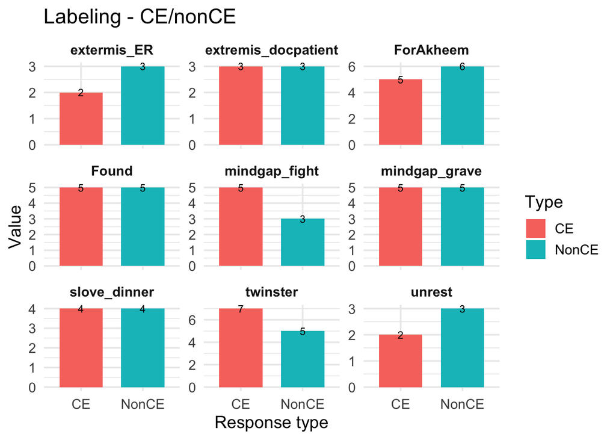

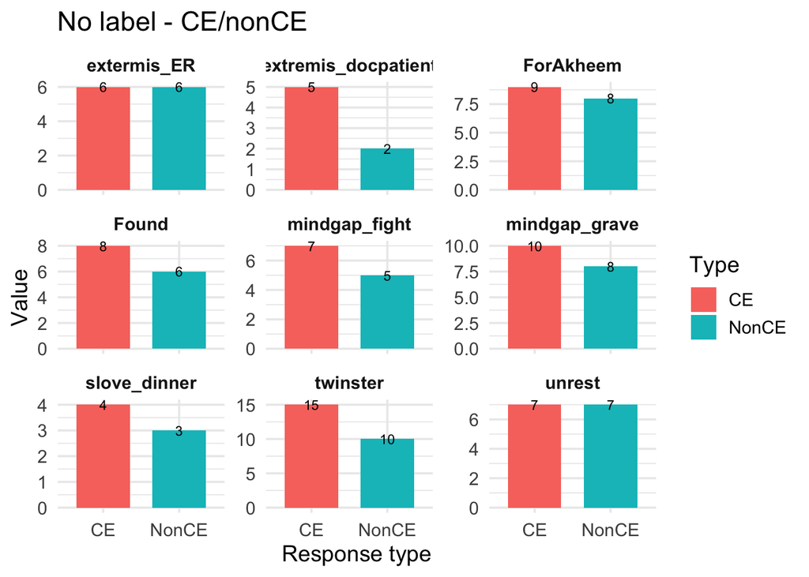

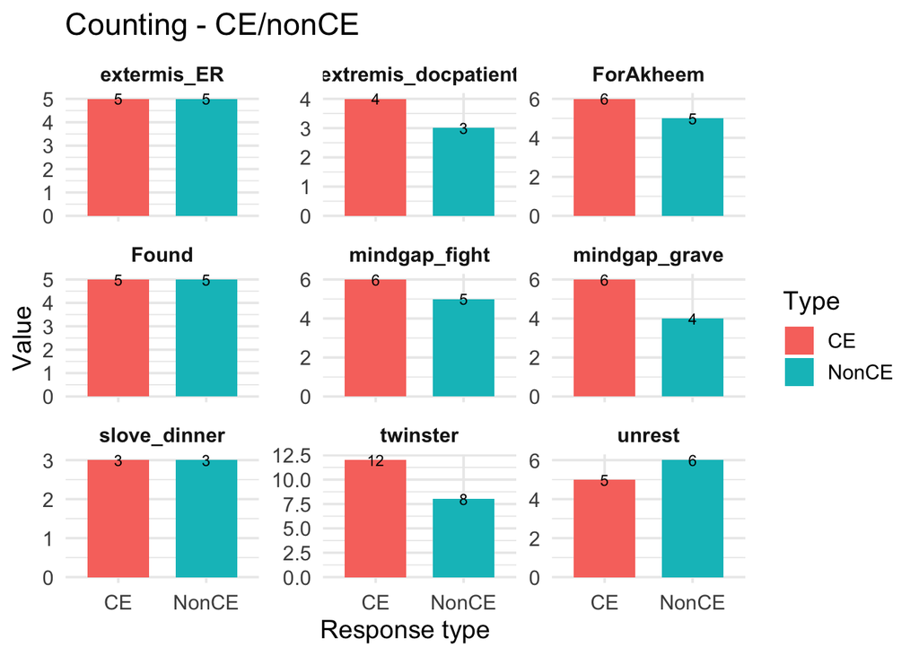

## Proportion of decision/response (hit, miss, fa, cr)

Labeling - Response proportion

| Stimuli | hit | miss | cr | fa |
| --- | --- | --- | --- | --- |
| ER_scene | 0.64 | 0.36 | 0.47 | 0.53 |
| campsite_dispute | 0.36 | 0.64 | 0.53 | 0.47 |
| childcare_dispute | 0.59 | 0.41 | 0.46 | 0.54 |
| dinner_chat | 0.58 | 0.42 | 0.69 | 0.31 |
| doc_patient_chat | 0.51 | 0.49 | 0.46 | 0.54 |
| girls_chat | 0.52 | 0.48 | 0.69 | 0.31 |
| graveside_reunion | 0.50 | 0.50 | 0.63 | 0.37 |
| pregnancy_reveal | 0.70 | 0.30 | 0.41 | 0.59 |
| twins_reunion | 0.71 | 0.29 | 0.52 | 0.48 |

No label - Response proportion

| Stimuli | hit | miss | cr | fa |
| --- | --- | --- | --- | --- |
| ER_scene | 0.46 | 0.54 | 0.65 | 0.35 |
| campsite_dispute | 0.63 | 0.37 | 0.52 | 0.48 |
| childcare_dispute | 0.70 | 0.30 | 0.47 | 0.53 |
| dinner_chat | 0.71 | 0.29 | 0.51 | 0.49 |
| doc_patient_chat | 0.69 | 0.31 | 0.35 | 0.65 |
| girls_chat | 0.70 | 0.30 | 0.54 | 0.46 |
| graveside_reunion | 0.62 | 0.38 | 0.62 | 0.38 |
| pregnancy_reveal | 0.66 | 0.34 | 0.60 | 0.40 |
| twins_reunion | 0.71 | 0.29 | 0.50 | 0.50 |

Counting - Response proportion

| Stimuli | hit | miss | cr | fa |
| --- | --- | --- | --- | --- |
| ER_scene | 0.49 | 0.51 | 0.78 | 0.22 |
| campsite_dispute | 0.60 | 0.40 | 0.54 | 0.46 |
| childcare_dispute | 0.66 | 0.34 | 0.59 | 0.41 |
| dinner_chat | 0.70 | 0.30 | 0.57 | 0.43 |
| doc_patient_chat | 0.50 | 0.50 | 0.49 | 0.51 |
| girls_chat | 0.71 | 0.29 | 0.58 | 0.42 |
| graveside_reunion | 0.59 | 0.41 | 0.40 | 0.60 |
| pregnancy_reveal | 0.71 | 0.29 | 0.40 | 0.60 |
| twins_reunion | 0.69 | 0.31 | 0.66 | 0.34 |

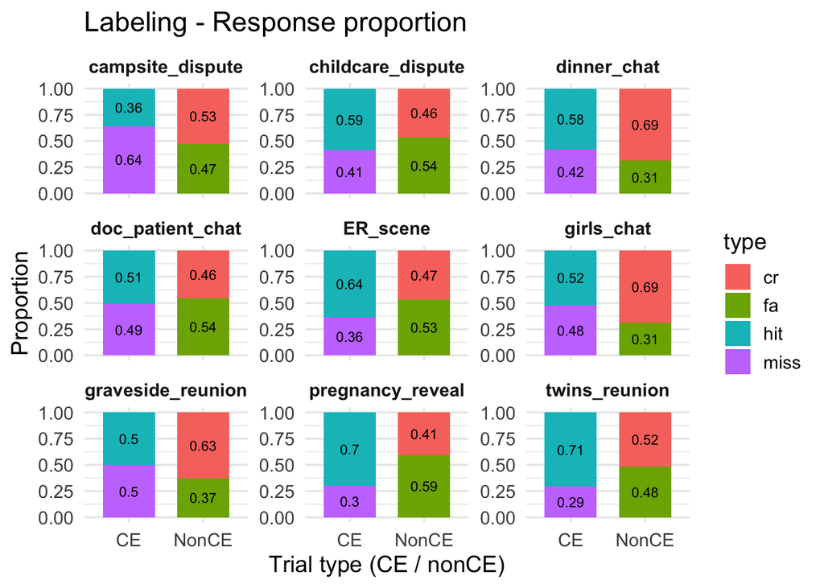

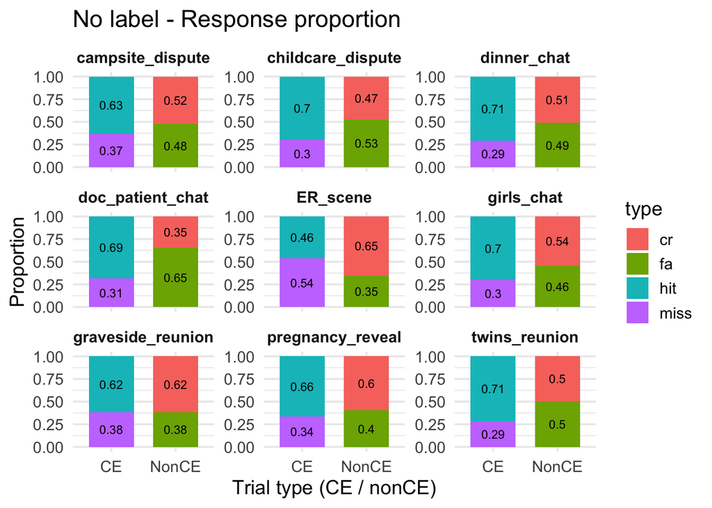

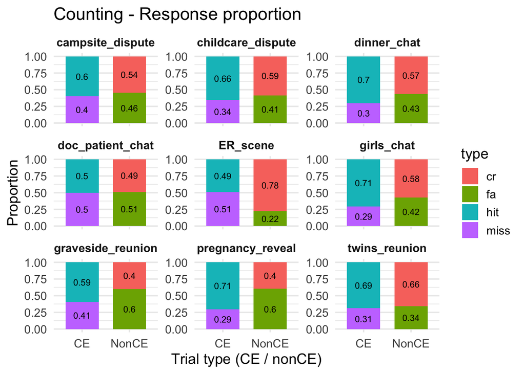

# ANOVA - group difference in emo seg

```
##
##  Shapiro-Wilk normality test
##
## data:  FULL$dprime
## W = 0.99517, p-value = 0.8367
```

```
##
##  Shapiro-Wilk normality test
##
## data:  FULL$STEU_score
## W = 0.96903, p-value = 0.0005173
```

```
## Levene's Test for Homogeneity of Variance (center = median)
##        Df F value Pr(>F)
## group   2  0.2511 0.7783
##       175
```

```
## Levene's Test for Homogeneity of Variance (center = median)
##        Df F value Pr(>F)
## group   2  1.1353 0.3237
##       176
```

## CEA

```
##              Df Sum Sq Mean Sq F value Pr(>F)
## condition     2  0.061 0.03034   1.196  0.305
## Residuals   177  4.488 0.02536
```

```
##   Tukey multiple comparisons of means
##     95% family-wise confidence level
##
## Fit: aov(formula = CEA_ave ~ condition, data = all)
##
## $condition
##                           diff         lwr        upr     p adj
## NoLabel-Counting    0.01807572 -0.05054664 0.08669809 0.8079350
## WithLabel-Counting -0.02609590 -0.09631457 0.04412277 0.6546250
## WithLabel-NoLabel  -0.04417162 -0.11185030 0.02350705 0.2735949
```

## accuracy

main effect of condition in accuracy

```
##              Df Sum Sq Mean Sq F value   Pr(>F)
## condition     2 0.0813 0.04066   11.19 2.68e-05 ***
## Residuals   175 0.6361 0.00363
## ---
## Signif. codes:  0 '***' 0.001 '**' 0.01 '*' 0.05 '.' 0.1 ' ' 1
## 2 observations deleted due to missingness
```

### pairwise comparison

labeling lower than nolabel and counting, counting - no label no difference

```r
tukey_result <- TukeyHSD(fit4)
print(tukey_result)
```

```
##   Tukey multiple comparisons of means
##     95% family-wise confidence level
##
## Fit: aov(formula = accuracy ~ condition, data = all)
##
## $condition
##                            diff         lwr         upr     p adj
## NoLabel-Counting   -0.001992606 -0.02823261  0.02424740 0.9823952
## WithLabel-Counting -0.046458987 -0.07329761 -0.01962036 0.0001919
## WithLabel-NoLabel  -0.044466381 -0.07009187 -0.01884089 0.0001846
```

### effect size

```r
eta_squared(fit4)
```

```
## For one-way between subjects designs, partial eta squared is equivalent
##   to eta squared. Returning eta squared.
```

```
## # Effect Size for ANOVA
##
## Parameter |   η² |       95% CI
## -------------------------------
## condition | 0.11 | [0.05, 1.00]
##
## - One-sided CIs: upper bound fixed at [1.00].
```

## dprime

main effect of condition in dprime

```
##              Df Sum Sq Mean Sq F value   Pr(>F)
## condition     2  2.133  1.0663   9.138 0.000168 ***
## Residuals   175 20.419  0.1167
## ---
## Signif. codes:  0 '***' 0.001 '**' 0.01 '*' 0.05 '.' 0.1 ' ' 1
## 2 observations deleted due to missingness
```

### pairwise comparison

no labeling no difference in dprime with counting, both higher than with-label

```r
#pairwise:
options(es.use_symbols = TRUE)
tukey_result <- TukeyHSD(fit1)
print(tukey_result) #
```

```
##   Tukey multiple comparisons of means
##     95% family-wise confidence level
##
## Fit: aov(formula = dprime ~ condition, data = all)
##
## $condition
##                            diff        lwr         upr     p adj
## NoLabel-Counting   -0.005512525 -0.1539756  0.14295051 0.9957619
## WithLabel-Counting -0.235434636 -0.3867773 -0.08409201 0.0009108
## WithLabel-NoLabel  -0.229922111 -0.3756534 -0.08419084 0.0007542
```

### effect size

```r
eta_squared(fit1) #eta2 = 0.09
```

```
## For one-way between subjects designs, partial eta squared is equivalent
##   to eta squared. Returning eta squared.
```

```
## # Effect Size for ANOVA
##
## Parameter |   η² |       95% CI
## -------------------------------
## condition | 0.09 | [0.03, 1.00]
##
## - One-sided CIs: upper bound fixed at [1.00].
```

## c

no main effect of condition in c

```
##              Df Sum Sq Mean Sq F value Pr(>F)
## condition     2  0.236  0.1178   0.688  0.504
## Residuals   176 30.168  0.1714
## 1 observation deleted due to missingness
```

```
##   Tukey multiple comparisons of means
##     95% family-wise confidence level
##
## Fit: aov(formula = c ~ condition, data = all)
##
## $condition
##                           diff        lwr       upr     p adj
## NoLabel-Counting   -0.05368891 -0.2327575 0.1253796 0.7586790
## WithLabel-Counting  0.03286900 -0.1497061 0.2154441 0.9050713
## WithLabel-NoLabel   0.08655791 -0.0900659 0.2631817 0.4796697
```

##deviation from optimal c main effect of condition in deviation from optimal c

```
##              Df Sum Sq Mean Sq F value Pr(>F)
## condition     2   1.50  0.7486   3.963 0.0208 *
## Residuals   173  32.68  0.1889
## ---
## Signif. codes:  0 '***' 0.001 '**' 0.01 '*' 0.05 '.' 0.1 ' ' 1
## 4 observations deleted due to missingness
```

### pairwise comparison

labeling group deviate less than nolabeling group and marginally lower than the counting group; no difference between counting and nolabel group

```r
tukey_result <- TukeyHSD(fit5)
print(tukey_result)
```

```
##   Tukey multiple comparisons of means
##     95% family-wise confidence level
##
## Fit: aov(formula = ave.c.devi ~ condition, data = all)
##
## $condition
##                           diff        lwr          upr     p adj
## NoLabel-Counting    0.01027249 -0.1805448  0.201089777 0.9911107
## WithLabel-Counting -0.18955408 -0.3839995  0.004891368 0.0578046
## WithLabel-NoLabel  -0.19982657 -0.3852605 -0.014392609 0.0313030
```

### effect size

```r
eta_squared(fit5) #eta2 = 0.04
```

```
## For one-way between subjects designs, partial eta squared is equivalent
##   to eta squared. Returning eta squared.
```

```
## # Effect Size for ANOVA
##
## Parameter |   η² |       95% CI
## -------------------------------
## condition | 0.04 | [0.00, 1.00]
##
## - One-sided CIs: upper bound fixed at [1.00].
```